# BostonGene Kuzmichenko

Холангиокарцинома - злокачественное новообразование эпителиальных клеток желчных протоков. Современная классификация основанана на анатомическом расположении:

- внутрипеченочная (iCCA)
- околокорневая (pCCA)
- дистальная (dCCA)

Эта опухоль имеет богатое микроокружение, глубокую генетическую гетерогенность( т.е один патологический фенотип обусловлен различными мутациями в одном и том же гене (аллельная гетерогенность) либо мутациями в различных генах (локусная гетерогенность)) все это способствует ее резистентности , поэтому показатели жививаемости низкие. Холангиокарциномы являются агрессивными опухолями, и у большинства пациентов заболевание проявляется на поздних стадиях. Как сообщается в статье [1], совокупная смертность от холангиокарциномы увеличилась на 39% из-за роста заболеваемости. В [2] приводится более подробный анализ смертности по разным видам холангиокарцином.

Факторы риска:цирроз,гепатит B,гепатит C, холангит и различные поражения желчных потоков.Opisthorchis viverrini и Clonorchis sinensis являются факторами риска холангиокарциномы.Выявлено несколько генетических полиморфизмов, повышающих риск развития холангиокарциномы.Достижения в комплексном секвенировании всего экзома и транскриптома определили генетический ландшафт каждого подтипа холангиокарциномы. Соответственно, были определены многообещающие молекулярные мишени для прецизионной медицины.

Существуют целые таблицы с названиями онкогенов.Я приведу одну ниже, опишу некоторые из важных сигнальные путей и генов.

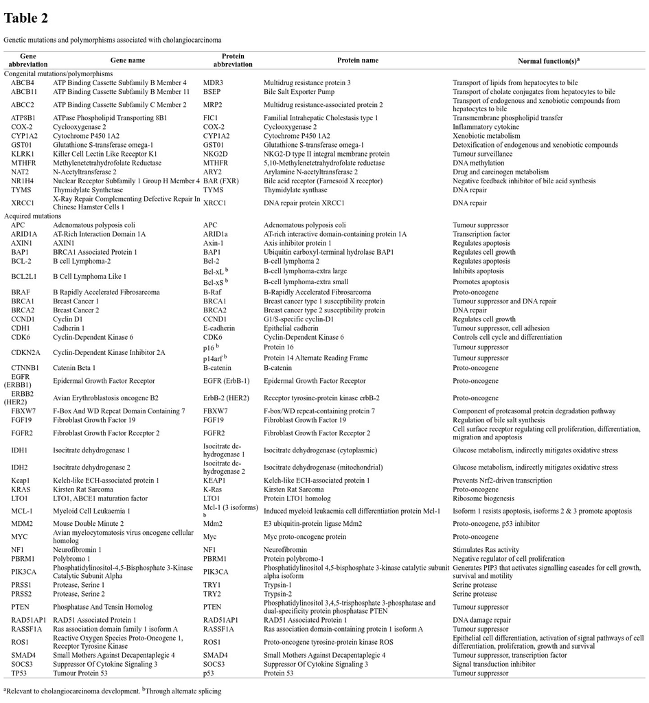

```python
display(Image('doi_ 10.1186_s12885-019-5391-0.jpg',width=800))
```

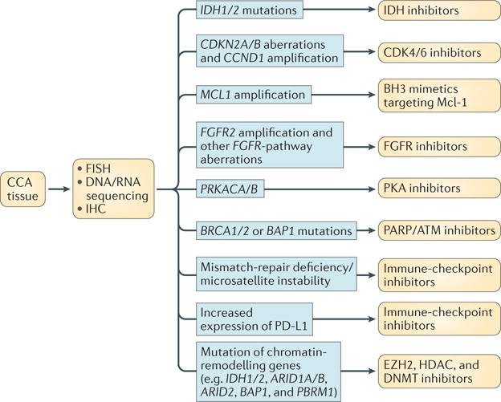

```python
from IPython.display import HTML, Image
display(Image("molecularstratification.jpg",width=400))
```

Путь Ras-MAPK является одним из основных сигнальных сетей в биологии холангиокарциномы.Белки, кодируемые генами соответвующего сигнального пути, стимулируют пролиферацию клеток, способствуют выживанию клеток. Фактор транскрипции STAT3 модулирует рост и выживаемость клеток и участвует в канцерогенезе. Помимо неконтролируемой клеточной пролиферации неопластическая трансформация также может быть достигнута за счет уклонения от апоптоза, облегчения миграции клеток (т.е. метастатического потенциала), устойчивости к гипоксии и повышенной васкуляризации.

Мутации KRAS были связаны с нарушением регуляции эпидермального фактора роста (EGFR) и сигнальной сети ERBB2 (также известной как HER2). Нарушение генов, участвующих в протеасомной активности, было связано с неблагоприятным прогнозом. Также показан терапевтический потенциал ингибирования тирозинкиназы в клеточных линиях холангиокарциномы с активированными EGFR и HER2.

Передача сигналов Notch жизненно важна для детерминации клеточных судеб и регулирует формирование желчных протоков, также отвечает за клеточную пролиферацию и апоптоз. Экспериментальные исследования также показали важную роль сигнального пути выживания Hh при холангиокарциноме.

Несколько групп недавно сообщили, что мутации «горячих точек» генов, кодирующих IDH1 и IDH2, довольно специфичны для внутрипеченочной холангиокарциномы при различных видах рака желудочно-кишечного тракта и желчных путей (10–23%).Эти мутации обычно идентифицируют в связи с глобальным гиперметилированием ДНК, что приводит к множественным эпигенетическим изменениям.

[1]- Cholangiocarcinoma Nataliya Razumilava, MD Prof Gregory J Gores, MD

[2]- Cholangiocarcinoma — evolving concepts and therapeutic strategies Sumera Rizvi,1 Shahid A. Khan,2,3 Christopher L. Hallemeier,4 Robin K. Kelley,5 and Gregory J. Gores1

[3] - Сиа Д, Хосида Ю, Вильянуэва А и другие. Интегративный молекулярный анализ внутрипеченочной холангиокарциномы выявляет 2 класса, которые имеют разные исходы. Гастроэнтерология. 2013; 144 : 829-840

## 2

Будем анализировать образцы холангиокарциномы из TCGA.Также скачаем для данного датасета экспрессию для образцов

```python
import pandas as pd
```

```python
sample = pd.read_csv("TCGA-CHOL.htseq_fpkm.tsv",sep="\t")
```

```python
for i in range(60482):
    sample['Ensembl_ID'][i] = sample['Ensembl_ID'][i].split('.')[0]
sample.head()
```

|  | Ensembl_ID | TCGA-ZD-A8I3-01A | TCGA-W5-AA2U-11A | TCGA-W5-AA30-01A | TCGA-W5-AA38-01A | TCGA-W5-AA30-11A | TCGA-YR-A95A-01A | TCGA-W5-AA36-01A | TCGA-W5-AA2U-01A | TCGA-ZH-A8Y2-01A | ... | TCGA-W5-AA2Q-11A | TCGA-W5-AA31-11A | TCGA-ZH-A8Y4-01A | TCGA-W5-AA2T-01A | TCGA-W5-AA2X-11A | TCGA-4G-AAZT-01A | TCGA-3X-AAV9-01A | TCGA-ZU-A8S4-11A | TCGA-W5-AA2I-01A | TCGA-W5-AA2G-01A |
| --- | --- | --- | --- | --- | --- | --- | --- | --- | --- | --- | --- | --- | --- | --- | --- | --- | --- | --- | --- | --- | --- |
| 0 | ENSG00000242268 | 0.090591 | 0.000000 | 0.000000 | 0.000000 | 0.000000 | 0.000000 | 0.000000 | 0.000000 | 0.000000 | ... | 0.000000 | 0.038126 | 0.122824 | 0.000000 | 0.052142 | 0.000000 | 0.000000 | 0.000000 | 0.000000 | 0.000000 |
| 1 | ENSG00000270112 | 0.000000 | 0.000000 | 0.000000 | 0.000000 | 0.000000 | 0.000000 | 0.006963 | 0.000000 | 0.000000 | ... | 0.000000 | 0.000000 | 0.000000 | 0.006618 | 0.000000 | 0.000000 | 0.000000 | 0.000000 | 0.013530 | 0.000000 |
| 2 | ENSG00000167578 | 1.916750 | 1.077140 | 2.049797 | 2.734908 | 1.383986 | 1.752605 | 2.079231 | 1.333563 | 2.373319 | ... | 1.484799 | 0.978705 | 1.943826 | 1.447376 | 1.464062 | 3.070124 | 2.282254 | 1.092823 | 2.008939 | 1.299082 |
| 3 | ENSG00000273842 | 0.000000 | 0.000000 | 0.000000 | 0.000000 | 0.000000 | 0.000000 | 0.000000 | 0.000000 | 0.000000 | ... | 0.000000 | 0.000000 | 0.000000 | 0.000000 | 0.000000 | 0.000000 | 0.000000 | 0.000000 | 0.000000 | 0.000000 |
| 4 | ENSG00000078237 | 2.412163 | 0.601511 | 1.822222 | 3.787181 | 0.596028 | 1.945475 | 1.134646 | 1.633560 | 1.626554 | ... | 0.864306 | 0.681485 | 1.355230 | 1.220890 | 1.510854 | 0.820853 | 2.115351 | 0.802964 | 1.097853 | 1.651701 |

5 rows × 46 columns

```python
sample.to_csv('sample.csv')
```

Чтобы анализировать данные, посмотрим на свойства данного датасета

```python
sample.shape
```

```
(60483, 46)
```

```python
sample.head()
```

|  | Ensembl_ID | TCGA-ZD-A8I3-01A | TCGA-W5-AA2U-11A | TCGA-W5-AA30-01A | TCGA-W5-AA38-01A | TCGA-W5-AA30-11A | TCGA-YR-A95A-01A | TCGA-W5-AA36-01A | TCGA-W5-AA2U-01A | TCGA-ZH-A8Y2-01A | ... | TCGA-W5-AA2Q-11A | TCGA-W5-AA31-11A | TCGA-ZH-A8Y4-01A | TCGA-W5-AA2T-01A | TCGA-W5-AA2X-11A | TCGA-4G-AAZT-01A | TCGA-3X-AAV9-01A | TCGA-ZU-A8S4-11A | TCGA-W5-AA2I-01A | TCGA-W5-AA2G-01A |
| --- | --- | --- | --- | --- | --- | --- | --- | --- | --- | --- | --- | --- | --- | --- | --- | --- | --- | --- | --- | --- | --- |
| 0 | ENSG00000242268 | 0.090591 | 0.000000 | 0.000000 | 0.000000 | 0.000000 | 0.000000 | 0.000000 | 0.000000 | 0.000000 | ... | 0.000000 | 0.038126 | 0.122824 | 0.000000 | 0.052142 | 0.000000 | 0.000000 | 0.000000 | 0.000000 | 0.000000 |
| 1 | ENSG00000270112 | 0.000000 | 0.000000 | 0.000000 | 0.000000 | 0.000000 | 0.000000 | 0.006963 | 0.000000 | 0.000000 | ... | 0.000000 | 0.000000 | 0.000000 | 0.006618 | 0.000000 | 0.000000 | 0.000000 | 0.000000 | 0.013530 | 0.000000 |
| 2 | ENSG00000167578 | 1.916750 | 1.077140 | 2.049797 | 2.734908 | 1.383986 | 1.752605 | 2.079231 | 1.333563 | 2.373319 | ... | 1.484799 | 0.978705 | 1.943826 | 1.447376 | 1.464062 | 3.070124 | 2.282254 | 1.092823 | 2.008939 | 1.299082 |
| 3 | ENSG00000273842 | 0.000000 | 0.000000 | 0.000000 | 0.000000 | 0.000000 | 0.000000 | 0.000000 | 0.000000 | 0.000000 | ... | 0.000000 | 0.000000 | 0.000000 | 0.000000 | 0.000000 | 0.000000 | 0.000000 | 0.000000 | 0.000000 | 0.000000 |
| 4 | ENSG00000078237 | 2.412163 | 0.601511 | 1.822222 | 3.787181 | 0.596028 | 1.945475 | 1.134646 | 1.633560 | 1.626554 | ... | 0.864306 | 0.681485 | 1.355230 | 1.220890 | 1.510854 | 0.820853 | 2.115351 | 0.802964 | 1.097853 | 1.651701 |

5 rows × 46 columns

Каунты - это число ридов, откартированных на ген или транскрипт.Число каунтов зависит от:

1. экспрессии гена,
2. размера библиотеки,
3. длины и GC-состава гена.

Для того, чтобы учесть длину гена и глубину секвенирования, придумали метрику FPKM(fragments per kilobase million)

Так как много различных библиотек написано на R, поэтому в свой работе я буду к ним обращаться

```python
import rpy2
from rpy2.robjects import r, pandas2ri

%load_ext rpy2.ipython
pandas2ri.activate()
```

Имя гена записано через его идентификатор в Ensembl. Переведём идентификатор в имя гена .Для этого в разделе BioMart скачала таблицу, где создала биекцию между транскриптом и названием гена.Назовем этот файл аннотацией

```python
%%R
annot = read.delim('mart_export.txt', header=T)
head(annot)
```

```
   Gene.stable.ID Gene.name
1 ENSG00000210049     MT-TF
2 ENSG00000211459   MT-RNR1
3 ENSG00000210077     MT-TV
4 ENSG00000210082   MT-RNR2
5 ENSG00000209082    MT-TL1
6 ENSG00000198888    MT-ND1
```

Откроем файл в R

```python
%%R
ensemblID = read.csv('sample.csv')
head(ensemblID)
```

```
  X      Ensembl_ID TCGA.ZD.A8I3.01A TCGA.W5.AA2U.11A TCGA.W5.AA30.01A
1 0 ENSG00000242268       0.09059121        0.0000000         0.000000
2 1 ENSG00000270112       0.00000000        0.0000000         0.000000
3 2 ENSG00000167578       1.91674955        1.0771398         2.049797
4 3 ENSG00000273842       0.00000000        0.0000000         0.000000
5 4 ENSG00000078237       2.41216268        0.6015109         1.822222
6 5 ENSG00000146083       4.31594180        1.6881915         4.310818
  TCGA.W5.AA38.01A TCGA.W5.AA30.11A TCGA.YR.A95A.01A TCGA.W5.AA36.01A
1         0.000000        0.0000000         0.000000      0.000000000
2         0.000000        0.0000000         0.000000      0.006963035
3         2.734908        1.3839861         1.752605      2.079230720
4         0.000000        0.0000000         0.000000      0.000000000
5         3.787181        0.5960279         1.945475      1.134645539
6         3.684790        1.6505648         3.481892      3.875511665
  TCGA.W5.AA2U.01A TCGA.ZH.A8Y2.01A TCGA.3X.AAVB.01A TCGA.W5.AA2Q.01A
```

[output cut: 69 more lines]

```python
%%R
merged.file = merge(ensemblID, annot, by.x='Ensembl_ID', by.y='Gene.stable.ID')
```

```python
%%R
merged.file= merged.file[,c(-1,-2)]
head(merged.file)
```

```
  TCGA.ZD.A8I3.01A TCGA.W5.AA2U.11A TCGA.W5.AA30.01A TCGA.W5.AA38.01A
1       4.78940644       3.76085283         4.757839       5.36425418
2       0.02046966       0.02046167         0.000000       0.01966479
3       4.59105650       3.75273380         5.016156       5.00212639
4       1.81429907       1.10838611         3.303226       1.41471507
5       1.27891681       0.17764793         2.330096       1.07023548
6       0.96125740       1.61294825         1.809512       1.10940410
  TCGA.W5.AA30.11A TCGA.YR.A95A.01A TCGA.W5.AA36.01A TCGA.W5.AA2U.01A
1       3.98335676        5.6964121         3.874724        5.1253483
2       0.01938629        0.1915949         0.000000        0.0183764
3       3.64116453        4.6505607         4.759668        4.4217907
4       1.12662951        2.1402841         1.491987        2.1849834
5       0.44118074        0.7102854         0.594848        0.9617783
6       1.29913242        0.9955876         1.239462        1.4885292
  TCGA.ZH.A8Y2.01A TCGA.3X.AAVB.01A TCGA.W5.AA2Q.01A TCGA.W5.AA2Z.01A
```

[output cut: 69 more lines]

```python
%%R
write.csv(merged.file, file = "merged.file.csv")
```

В merged.file.csv хранится таблица с экспрессиями, только вместо ensg, названия генов.

## 4,5

Посмотрим на аннотацию для сэмплов. Её получили также из TCGA.

```python
phenotype = pd.read_csv('TCGA-CHOL.GDC_phenotype.tsv', sep="\t")
```

```python
phenotype.head()
```

|  | submitter_id.samples | age_at_initial_pathologic_diagnosis | albumin_result_lower_limit | albumin_result_specified_value | albumin_result_upper_limit | batch_number | bcr | bcr_followup_barcode | bcr_followup_uuid | submitter_id | ... | days_to_collection.samples | days_to_sample_procurement.samples | initial_weight.samples | is_ffpe.samples | oct_embedded.samples | preservation_method.samples | sample_type.samples | sample_type_id.samples | state.samples | tissue_type.samples |
| --- | --- | --- | --- | --- | --- | --- | --- | --- | --- | --- | --- | --- | --- | --- | --- | --- | --- | --- | --- | --- | --- |
| 0 | TCGA-ZH-A8Y2-01A | 59.0 | NaN | NaN | NaN | 428.25.0 | Nationwide Children's Hospital | NaN | NaN | TCGA-ZH-A8Y2 | ... | 897.0 | NaN | 400.0 | False | False | NaN | Primary Tumor | 1 | released | Not Reported |
| 1 | TCGA-ZH-A8Y7-01A | 59.0 | 3.5 | 2.4 | 5.0 | 448.13.0 | Nationwide Children's Hospital | NaN | NaN | TCGA-ZH-A8Y7 | ... | 77.0 | NaN | 1100.0 | False | False | NaN | Primary Tumor | 1 | released | Not Reported |
| 2 | TCGA-W7-A93O-01A | NaN | NaN | NaN | NaN | 448.13.0 | Nationwide Children's Hospital | NaN | NaN | TCGA-W7-A93O | ... | 465.0 | NaN | 180.0 | False | True | NaN | Primary Tumor | 1 | released | Not Reported |
| 3 | TCGA-W7-A93O-11A | NaN | NaN | NaN | NaN | 448.13.0 | Nationwide Children's Hospital | NaN | NaN | TCGA-W7-A93O | ... | 465.0 | NaN | 180.0 | False | True | NaN | Solid Tissue Normal | 11 | released | Not Reported |
| 4 | TCGA-W5-AA30-01A | 82.0 | 3.5 | 4.3 | 5.0 | 428.25.0 | Nationwide Children's Hospital | TCGA-W5-AA30-F66610 | B7D96997-EC27-438D-95D7-16B1817F93FB | TCGA-W5-AA30 | ... | 1134.0 | NaN | 200.0 | False | True | NaN | Primary Tumor | 1 | released | Not Reported |

5 rows × 122 columns

Батч-эффект возникает из-за различных факторов: например, замер в дневное и вечернее время, ошибки прибора или исследователей

Анализ главных компонентов (PCA) — это метод уменьшения линейной размерности , который можно использовать для извлечения информации из многомерного пространства путем проецирования ее в подпространство более низкого измерения. Он пытается сохранить важные части, которые имеют больше вариаций данных, и удалить несущественные части с меньшими вариациями. Таким образом, можно избавиться от батч-эффекта и ускорить алгоритмы прогонки.

PCA зависит от масштаба, поэтому необходимо масштабировать функции в ваших данных перед применением PCA.

Разобьем наши данные, чтобы можно было применять PCA

```python
sample.pop('Ensembl_ID')
```

```
0          ENSG00000242268
1          ENSG00000270112
2          ENSG00000167578
3          ENSG00000273842
4          ENSG00000078237
               ...
60478      ENSG00000105063
60479      ENSG00000231119
60480      ENSG00000280861
60481      ENSG00000123685
60482    ENSG00000181518.3
Name: Ensembl_ID, Length: 60483, dtype: object
```

```python
sample.head()
```

|  | TCGA-ZD-A8I3-01A | TCGA-W5-AA2U-11A | TCGA-W5-AA30-01A | TCGA-W5-AA38-01A | TCGA-W5-AA30-11A | TCGA-YR-A95A-01A | TCGA-W5-AA36-01A | TCGA-W5-AA2U-01A | TCGA-ZH-A8Y2-01A | TCGA-3X-AAVB-01A | ... | TCGA-W5-AA2Q-11A | TCGA-W5-AA31-11A | TCGA-ZH-A8Y4-01A | TCGA-W5-AA2T-01A | TCGA-W5-AA2X-11A | TCGA-4G-AAZT-01A | TCGA-3X-AAV9-01A | TCGA-ZU-A8S4-11A | TCGA-W5-AA2I-01A | TCGA-W5-AA2G-01A |
| --- | --- | --- | --- | --- | --- | --- | --- | --- | --- | --- | --- | --- | --- | --- | --- | --- | --- | --- | --- | --- | --- |
| 0 | 0.090591 | 0.000000 | 0.000000 | 0.000000 | 0.000000 | 0.000000 | 0.000000 | 0.000000 | 0.000000 | 0.043806 | ... | 0.000000 | 0.038126 | 0.122824 | 0.000000 | 0.052142 | 0.000000 | 0.000000 | 0.000000 | 0.000000 | 0.000000 |
| 1 | 0.000000 | 0.000000 | 0.000000 | 0.000000 | 0.000000 | 0.000000 | 0.006963 | 0.000000 | 0.000000 | 0.036561 | ... | 0.000000 | 0.000000 | 0.000000 | 0.006618 | 0.000000 | 0.000000 | 0.000000 | 0.000000 | 0.013530 | 0.000000 |
| 2 | 1.916750 | 1.077140 | 2.049797 | 2.734908 | 1.383986 | 1.752605 | 2.079231 | 1.333563 | 2.373319 | 2.360779 | ... | 1.484799 | 0.978705 | 1.943826 | 1.447376 | 1.464062 | 3.070124 | 2.282254 | 1.092823 | 2.008939 | 1.299082 |
| 3 | 0.000000 | 0.000000 | 0.000000 | 0.000000 | 0.000000 | 0.000000 | 0.000000 | 0.000000 | 0.000000 | 0.000000 | ... | 0.000000 | 0.000000 | 0.000000 | 0.000000 | 0.000000 | 0.000000 | 0.000000 | 0.000000 | 0.000000 | 0.000000 |
| 4 | 2.412163 | 0.601511 | 1.822222 | 3.787181 | 0.596028 | 1.945475 | 1.134646 | 1.633560 | 1.626554 | 2.458518 | ... | 0.864306 | 0.681485 | 1.355230 | 1.220890 | 1.510854 | 0.820853 | 2.115351 | 0.802964 | 1.097853 | 1.651701 |

5 rows × 45 columns

```python
sample.columns
```

[output not shown]

В sklearn представлена функция PCA.Уменьшение линейной размерности с использованием разложения данных по сингулярным значениям для проецирования их в пространство более низкой размерности. Входные данные центрируются, но не масштабируются для каждой функции перед применением SVD.

Он использует реализацию LAPACK полного SVD или рандомизированного усеченного SVD по методу Halko et al. 2009, в зависимости от формы входных данных и количества компонентов для извлечения.

```python
from sklearn.decomposition import PCA
from matplotlib import pylab as plt
import numpy as np
from sklearn.preprocessing import StandardScaler
```

PCA зависит от масштаба, поэтому необходимо масштабировать объекты в данных перед применением алгоритма. Используем StandardScaler, затем обучим модель.PCA - обучение без учителя

```python
x = StandardScaler().fit_transform(sample.T)
```

```python
pca = PCA(n_components=2)
principalComponents = pca.fit_transform(x)
principalDf = pd.DataFrame(data = principalComponents
             , columns = ['principal component_1', 'principal component_2'])
```

```python
principalDf
```

|  | principal component_1 | principal component_2 |
| --- | --- | --- |
| 0 | -70.028385 | -35.682047 |
| 1 | 182.719245 | 15.375468 |
| 2 | -95.318237 | -1.975661 |
| 3 | 0.330110 | -24.817659 |
| 4 | 176.121941 | 19.027000 |
| 5 | -7.524414 | -29.616651 |
| 6 | 0.861414 | -9.638655 |
| 7 | -49.077662 | -32.391660 |
| 8 | -73.204522 | -33.620789 |
| 9 | -49.774562 | 24.975610 |
| 10 | -78.134406 | -42.697505 |
| 11 | -59.494375 | -34.369688 |
| 12 | -27.395190 | -18.914942 |
| 13 | 178.608234 | -0.492144 |
| 14 | -27.914954 | -34.015847 |
| 15 | -74.791664 | -41.436020 |
| 16 | -21.731591 | 28.318368 |
| 17 | -104.419454 | 9.386868 |
| 18 | -105.268509 | 349.946371 |
| 19 | 176.388689 | 2.838246 |
| 20 | 192.331238 | 6.161106 |
| 21 | 41.177923 | -12.966892 |
| 22 | -21.308255 | -13.781999 |
| 23 | -49.634468 | 9.830625 |
| 24 | -55.855775 | 2.184532 |
| 25 | -97.211151 | 7.004600 |
| 26 | -57.900760 | -42.249523 |
| 27 | -60.721088 | -7.306420 |
| 28 | -47.048483 | 0.801320 |
| 29 | -14.049675 | 24.890298 |
| 30 | -29.006384 | -13.677705 |
| 31 | -21.176876 | -15.865047 |
| 32 | -42.203966 | -36.954031 |
| 33 | -24.152854 | -24.617336 |
| 34 | -65.983631 | -50.919023 |
| 35 | 157.925261 | 30.306776 |
| 36 | 191.344961 | 2.424491 |
| 37 | -35.251619 | -36.220292 |
| 38 | -100.877473 | -22.017359 |
| 39 | 146.127148 | 14.966607 |
| 40 | 0.190275 | 21.517404 |
| 41 | -65.239480 | 73.873543 |
| 42 | 195.710813 | 8.737329 |
| 43 | -21.067158 | -13.198666 |
| 44 | 12.929768 | -23.123001 |

большие дисперсии важны: предполагается, что наиболее важны те направления в данных, вдоль которых они имеют наибольшую дисперсию,

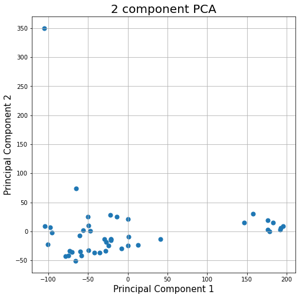

```python
fig = plt.figure(figsize = (8,8))
ax = fig.add_subplot(1,1,1)
ax.set_xlabel('Principal Component 1', fontsize = 15)
ax.set_ylabel('Principal Component 2', fontsize = 15)
ax.set_title('2 component PCA', fontsize = 20)

ax.scatter(principalDf[ 'principal component_1']
               , principalDf['principal component_2']

               , s = 50)
ax.grid()
```

Когда есть основные компоненты, можно найти файл explained_variance_ratio. Он предоставит объем информации или дисперсию, которую содержит каждый основной компонент после проецирования данных в подпространство более низкого измерения.

```python
pca.explained_variance_ratio_
```

```
array([0.17756512, 0.06813872])
```

Из приведенного выше вывода вы можете заметить, что principal component 1содержит 18% информации, а principal component 2содержит только 7% информации. Потеряно было 75% информации...

```python
principalDf['name_sample']=sample.columns
principalDf
```

|  | principal component_1 | principal component_2 | name_sample |
| --- | --- | --- | --- |
| 0 | -70.028385 | -35.682047 | TCGA-ZD-A8I3-01A |
| 1 | 182.719245 | 15.375468 | TCGA-W5-AA2U-11A |
| 2 | -95.318237 | -1.975661 | TCGA-W5-AA30-01A |
| 3 | 0.330110 | -24.817659 | TCGA-W5-AA38-01A |
| 4 | 176.121941 | 19.027000 | TCGA-W5-AA30-11A |
| 5 | -7.524414 | -29.616651 | TCGA-YR-A95A-01A |
| 6 | 0.861414 | -9.638655 | TCGA-W5-AA36-01A |
| 7 | -49.077662 | -32.391660 | TCGA-W5-AA2U-01A |
| 8 | -73.204522 | -33.620789 | TCGA-ZH-A8Y2-01A |
| 9 | -49.774562 | 24.975610 | TCGA-3X-AAVB-01A |
| 10 | -78.134406 | -42.697505 | TCGA-W5-AA2Q-01A |
| 11 | -59.494375 | -34.369688 | TCGA-W5-AA2Z-01A |
| 12 | -27.395190 | -18.914942 | TCGA-3X-AAVA-01A |
| 13 | 178.608234 | -0.492144 | TCGA-W5-AA34-11A |
| 14 | -27.914954 | -34.015847 | TCGA-ZH-A8Y6-01A |
| 15 | -74.791664 | -41.436020 | TCGA-ZH-A8Y1-01A |
| 16 | -21.731591 | 28.318368 | TCGA-ZU-A8S4-01A |
| 17 | -104.419454 | 9.386868 | TCGA-W5-AA2R-01A |
| 18 | -105.268509 | 349.946371 | TCGA-W5-AA2H-01A |
| 19 | 176.388689 | 2.838246 | TCGA-W5-AA2R-11A |
| 20 | 192.331238 | 6.161106 | TCGA-W5-AA2I-11A |
| 21 | 41.177923 | -12.966892 | TCGA-W5-AA39-01A |
| 22 | -21.308255 | -13.781999 | TCGA-W5-AA2O-01A |
| 23 | -49.634468 | 9.830625 | TCGA-3X-AAVC-01A |
| 24 | -55.855775 | 2.184532 | TCGA-3X-AAVE-01A |
| 25 | -97.211151 | 7.004600 | TCGA-W5-AA2X-01A |
| 26 | -57.900760 | -42.249523 | TCGA-ZH-A8Y5-01A |
| 27 | -60.721088 | -7.306420 | TCGA-W5-AA33-01A |
| 28 | -47.048483 | 0.801320 | TCGA-ZH-A8Y8-01A |
| 29 | -14.049675 | 24.890298 | TCGA-WD-A7RX-01A |
| 30 | -29.006384 | -13.677705 | TCGA-W5-AA34-01A |
| 31 | -21.176876 | -15.865047 | TCGA-W6-AA0S-01A |
| 32 | -42.203966 | -36.954031 | TCGA-4G-AAZO-01A |
| 33 | -24.152854 | -24.617336 | TCGA-W5-AA31-01A |
| 34 | -65.983631 | -50.919023 | TCGA-W5-AA2W-01A |
| 35 | 157.925261 | 30.306776 | TCGA-W5-AA2Q-11A |
| 36 | 191.344961 | 2.424491 | TCGA-W5-AA31-11A |
| 37 | -35.251619 | -36.220292 | TCGA-ZH-A8Y4-01A |
| 38 | -100.877473 | -22.017359 | TCGA-W5-AA2T-01A |
| 39 | 146.127148 | 14.966607 | TCGA-W5-AA2X-11A |
| 40 | 0.190275 | 21.517404 | TCGA-4G-AAZT-01A |
| 41 | -65.239480 | 73.873543 | TCGA-3X-AAV9-01A |
| 42 | 195.710813 | 8.737329 | TCGA-ZU-A8S4-11A |
| 43 | -21.067158 | -13.198666 | TCGA-W5-AA2I-01A |
| 44 | 12.929768 | -23.123001 | TCGA-W5-AA2G-01A |

```python
principalDf.sort_values(by='principal component_1')
```

[output not shown]

Будем смотреть на абсолютное значение. Таким образом, можно не учитывать сэмплы, что стоят в центре, и опираться на значения в первой колонке

Так как результаты получились не очень удовлетворительными, проверю, имеют ли нормализованные данные среднее значение, равное нулю, и стандартное отклонение, равное единице.

```python
np.mean(x),np.std(x)
```

```
(1.7552971911801758e-17, 0.922069786152475)
```

## 6

Построим PCA plot (2 компоненты) используя экспрессию, как свойства образцов, а данные о стадии заболевания (колонка в аннотации - tumor_stage.diagnoses) из аннотации как цвет точек.

```python
y=phenotype['tumor_stage.diagnoses']
```

```python
finalDf = pd.concat([principalDf, y], axis = 1)
```

```python
finalDf.head()
```

[output not shown]

```python
y.unique()
```

```
array(['stage i', 'stage ivb', 'stage iib', 'stage iv', 'stage iii',
       'stage ii', 'stage iva', nan], dtype=object)
```

[figure not shown]

```python
fig = plt.figure(figsize = (8,8))
ax = fig.add_subplot(1,1,1)
ax.set_xlabel('Principal Component 1', fontsize = 15)
ax.set_ylabel('Principal Component 2', fontsize = 15)
ax.set_title('2 component PCA', fontsize = 20)
targets= ['stage i', 'stage ivb', 'stage iib', 'stage iv', 'stage iii',
       'stage ii', 'stage iva', 'nan']
colors = ['r', 'g','b','y','aqua','black','silver','purple']
for target, color in zip(targets,colors):
    indicesToKeep = finalDf['tumor_stage.diagnoses'] == target
    ax.scatter(finalDf.loc[indicesToKeep, 'principal component 1']
               , finalDf.loc[indicesToKeep, 'principal component 2']
               , c = color
               , s = 50)
ax.legend(targets)
ax.grid()
```

```python
pca.explained_variance_ratio_
```

[output not shown]

## 8

В разделе «Mutations» скачала 4 таблицы с информацией о мутациях в образцах, полученной разными программами.

Найдём мутации, поддержанные всеми программами.Для этого изучим наши данные.

```python
mutation_1=pd.read_csv('TCGA-CHOL.muse_snv.tsv' ,sep="\t")
mutation_1.head()
```

|  | Sample_ID | gene | chrom | start | end | ref | alt | Amino_Acid_Change | effect | filter | dna_vaf |
| --- | --- | --- | --- | --- | --- | --- | --- | --- | --- | --- | --- |
| 0 | TCGA-ZH-A8Y2-01A | ST3GAL3 | chr1 | 43824770 | 43824770 | C | T | NaN | intron_variant | PASS | 0.178218 |
| 1 | TCGA-ZH-A8Y2-01A | SH3GLB1 | chr1 | 86735087 | 86735087 | C | G | p.H223Q | missense_variant | PASS | 0.168539 |
| 2 | TCGA-ZH-A8Y2-01A | POLR3C | chr1 | 145833282 | 145833282 | A | G | p.Y234C | missense_variant | PASS | 0.423077 |
| 3 | TCGA-ZH-A8Y2-01A | HDGF | chr1 | 156743657 | 156743657 | A | T | p.H237Q | missense_variant | PASS | 0.200000 |
| 4 | TCGA-ZH-A8Y2-01A | CEP350 | chr1 | 180111535 | 180111535 | A | G | NaN | 3_prime_UTR_variant | PASS | 0.186441 |

```python
mutation_2=pd.read_csv('TCGA-CHOL.mutect2_snv.tsv' ,sep="\t")
mutation_2.head()
```

|  | Sample_ID | gene | chrom | start | end | ref | alt | Amino_Acid_Change | effect | filter | dna_vaf |
| --- | --- | --- | --- | --- | --- | --- | --- | --- | --- | --- | --- |
| 0 | TCGA-4G-AAZR-01A | B4GALT2 | chr1 | 43981297 | 43981297 | G | T | p.S46I | missense_variant | PASS | 0.285714 |
| 1 | TCGA-4G-AAZR-01A | ATP8B2 | chr1 | 154342822 | 154342822 | C | T | p.F471F | synonymous_variant | PASS | 0.245614 |
| 2 | TCGA-4G-AAZR-01A | KIRREL | chr1 | 158078114 | 158078114 | C | T | p.S109F | missense_variant | PASS | 0.217391 |
| 3 | TCGA-4G-AAZR-01A | NRXN1 | chr2 | 50531423 | 50531423 | C | G | p.T717T | synonymous_variant | PASS | 0.137931 |
| 4 | TCGA-4G-AAZR-01A | TRABD2A | chr2 | 84839211 | 84839211 | T | G | p.K310T | missense_variant | PASS | 0.345455 |

```python
mutation_2.shape
```

```
(5503, 11)
```

```python
mutation_3=pd.read_csv('TCGA-CHOL.somaticsniper_snv.tsv' ,sep="\t")
mutation_3.head()
```

|  | Sample_ID | gene | chrom | start | end | ref | alt | Amino_Acid_Change | effect | filter | dna_vaf |
| --- | --- | --- | --- | --- | --- | --- | --- | --- | --- | --- | --- |
| 0 | TCGA-W5-AA2I-01A | EPHA2 | chr1 | 16125318 | 16125318 | T | A | p.D943V | missense_variant;splice_region_variant | PASS | 0.612903 |
| 1 | TCGA-W5-AA2I-01A | ZNF691 | chr1 | 42851568 | 42851568 | A | T | p.S235C | missense_variant | PASS | 0.285714 |
| 2 | TCGA-W5-AA2I-01A | CEP350 | chr1 | 180013916 | 180013916 | C | T | p.S488L | missense_variant | PASS | 0.333333 |
| 3 | TCGA-W5-AA2I-01A | EPRS | chr1 | 219978616 | 219978616 | T | A | p.N1338I | missense_variant | PASS | 0.348837 |
| 4 | TCGA-W5-AA2I-01A | ARHGEF4 | chr2 | 131045961 | 131045961 | C | A | NaN | intron_variant | PASS | 0.354839 |

```python
mutation_3.shape
```

```
(3507, 11)
```

```python
mutation_4=pd.read_csv('TCGA-CHOL.varscan2_snv.tsv' ,sep="\t")
mutation_4.head()
```

|  | Sample_ID | gene | chrom | start | end | ref | alt | Amino_Acid_Change | effect | filter | dna_vaf |
| --- | --- | --- | --- | --- | --- | --- | --- | --- | --- | --- | --- |
| 0 | TCGA-W5-AA2O-01A | CA6 | chr1 | 8967692 | 8967692 | A | G | p.Q202R | missense_variant | PASS | 0.730769 |
| 1 | TCGA-W5-AA2O-01A | VAV3 | chr1 | 107705062 | 107705062 | C | A | p.X501_splice | splice_acceptor_variant | PASS | 0.370968 |
| 2 | TCGA-W5-AA2O-01A | CH17-13I23.1 | chr1 | 143464806 | 143464806 | G | A | NaN | non_coding_transcript_exon_variant;non_coding_... | PASS | 0.769231 |
| 3 | TCGA-W5-AA2O-01A | ARHGEF2 | chr1 | 155983106 | 155983106 | C | T | NaN | upstream_gene_variant | PASS | 0.410256 |
| 4 | TCGA-W5-AA2O-01A | STON1-GTF2A1L | chr2 | 48669732 | 48669732 | C | T | p.S1034F | missense_variant | PASS | 0.430233 |

```python
mutation_4.shape
```

```
(5115, 11)
```

Делать цикл и в нем сравнивать поэлементно, мне не кажется разумным.Предположим, что start является неким уникальным ключом к описанию мутации, и сравним, есть ли одинаковые стартовые позиции в четырех таблицах

```python
c = list(set(mutation_1['start']  ) & set(mutation_2['start']  )
         & set(mutation_3['start']) & set(mutation_4['start'] ))
print(c)
```

```
[53264386, 169779212, 72196110, 64077838, 113803281, 33513493, 124985368, 43360282, 31776794, 3022879, 200613919, 55468065, 237387810, 12828707, 12787748, 152657954, 107929638, 43704359, 186343463, 102350889, 88875052, 56385581, 169877553, 78569524, 32710710, 39182390, 19390520, 55435322, 21971004, …
```

```python
len(c)
```

```
3028
```

Выглядит достаточно разумно, так как четыре таблицы описывают один и тот же рак, но сделаны в разных лабораториях

Сделаю таблицу с этими мутацииями, поддержанными всеми программами.

```python
mutation_0=pd.read_csv('TCGA-CHOL.muse_snv.tsv' ,sep="\t")
mutation_0 = mutation_0.query(f"start  in {c}")
```

```python
mutation_0.shape
```

```
(3033, 11)
```

На этом месте пришлось задуматься, ведь следуя моей логике, размер должен был быть 3028.Но я использовала set, чтобы найти ключи, следовательно одна стартовая позиция в самой таблице может соответствовать разным муациям. Проверим гипотезу

```python
ids = mutation_0['start']
mutation_0[ids.isin(ids[ids.duplicated()])].sort_values(by = 'start')
```

|  | Sample_ID | gene | chrom | start | end | ref | alt | Amino_Acid_Change | effect | filter | dna_vaf |
| --- | --- | --- | --- | --- | --- | --- | --- | --- | --- | --- | --- |
| 50 | TCGA-ZH-A8Y2-01A | ARAF | chrX | 47566728 | 47566728 | C | T | p.P216L | missense_variant | PASS | 0.654545 |
| 1485 | TCGA-ZH-A8Y4-01A | ARAF | chrX | 47566728 | 47566728 | C | T | p.P216L | missense_variant | PASS | 0.836066 |
| 194 | TCGA-YR-A95A-01A | IDH1 | chr2 | 208248389 | 208248389 | G | A | p.R132C | missense_variant | PASS | 0.421053 |
| 227 | TCGA-W5-AA34-01A | IDH1 | chr2 | 208248389 | 208248389 | G | A | p.R132C | missense_variant | PASS | 0.464286 |
| 1158 | TCGA-W5-AA36-01A | IDH1 | chr2 | 208248389 | 208248389 | G | T | p.R132S | missense_variant | PASS | 0.391304 |
| 1603 | TCGA-W5-AA2O-01A | IDH1 | chr2 | 208248389 | 208248389 | G | A | p.R132C | missense_variant | PASS | 0.524390 |
| 3663 | TCGA-W5-AA2G-01A | IDH1 | chr2 | 208248389 | 208248389 | G | A | p.R132C | missense_variant | PASS | 0.408163 |

Посмотрим, как обстоят дела в остальных таблицах

```python
mutation_2 = mutation_2.query(f"start in {c}")
ids = mutation_2['start']
print(mutation_2[ids.isin(ids[ids.duplicated()])].sort_values(by = 'start'))

print(mutation_2.shape)
```

```
             Sample_ID  gene chrom      start        end ref alt  \
773   TCGA-W5-AA36-01A  IDH1  chr2  208248389  208248389   G   T
4214  TCGA-W5-AA2O-01A  IDH1  chr2  208248389  208248389   G   A
4654  TCGA-W5-AA2G-01A  IDH1  chr2  208248389  208248389   G   A
5062  TCGA-W5-AA34-01A  IDH1  chr2  208248389  208248389   G   A
5461  TCGA-YR-A95A-01A  IDH1  chr2  208248389  208248389   G   A

     Amino_Acid_Change            effect filter   dna_vaf
773            p.R132S  missense_variant   PASS  0.395349
4214           p.R132C  missense_variant   PASS  0.549296
4654           p.R132C  missense_variant   PASS  0.408163
5062           p.R132C  missense_variant   PASS  0.444444
5461           p.R132C  missense_variant   PASS  0.421053
(3032, 11)
```

```python
mutation_3 = mutation_3.query(f"start in {c}")
ids = mutation_3['start']
print(mutation_3[ids.isin(ids[ids.duplicated()])].sort_values(by = 'start'))

print(mutation_3.shape)
```

```
             Sample_ID  gene chrom      start        end ref alt  \
102   TCGA-ZH-A8Y4-01A  ARAF  chrX   47566728   47566728   C   T
2503  TCGA-ZH-A8Y2-01A  ARAF  chrX   47566728   47566728   C   T
117   TCGA-W5-AA2G-01A  IDH1  chr2  208248389  208248389   G   A
915   TCGA-W5-AA2O-01A  IDH1  chr2  208248389  208248389   G   A
966   TCGA-W5-AA36-01A  IDH1  chr2  208248389  208248389   G   T
2802  TCGA-W5-AA34-01A  IDH1  chr2  208248389  208248389   G   A
3310  TCGA-YR-A95A-01A  IDH1  chr2  208248389  208248389   G   A

     Amino_Acid_Change            effect filter   dna_vaf
102            p.P216L  missense_variant   PASS  0.836066
2503           p.P216L  missense_variant   PASS  0.654545
117            p.R132C  missense_variant   PASS  0.408163
915            p.R132C  missense_variant   PASS  0.524390
966            p.R132S  missense_variant   PASS  0.391304
2802           p.R132C  missense_variant   PASS  0.464286
3310           p.R132C  missense_variant   PASS  0.421053
(3033, 11)
```

```python
mutation_4 = mutation_4.query(f"start in {c}")
ids = mutation_4['start']
print(mutation_4[ids.isin(ids[ids.duplicated()])].sort_values(by = 'start'))

print(mutation_4.shape)
```

```
             Sample_ID  gene chrom      start        end ref alt  \
3825  TCGA-ZH-A8Y2-01A  ARAF  chrX   47566728   47566728   C   T
3967  TCGA-ZH-A8Y4-01A  ARAF  chrX   47566728   47566728   C   T
5     TCGA-W5-AA2O-01A  IDH1  chr2  208248389  208248389   G   A
2019  TCGA-W5-AA2G-01A  IDH1  chr2  208248389  208248389   G   A
4135  TCGA-W5-AA34-01A  IDH1  chr2  208248389  208248389   G   A
4298  TCGA-W5-AA36-01A  IDH1  chr2  208248389  208248389   G   T
4903  TCGA-YR-A95A-01A  IDH1  chr2  208248389  208248389   G   A

     Amino_Acid_Change            effect filter   dna_vaf
3825           p.P216L  missense_variant   PASS  0.695652
3967           p.P216L  missense_variant   PASS  0.823529
5              p.R132C  missense_variant   PASS  0.544118
2019           p.R132C  missense_variant   PASS  0.386364
4135           p.R132C  missense_variant   PASS  0.470588
4298           p.R132S  missense_variant   PASS  0.372093
4903           p.R132C  missense_variant   PASS  0.400000
(3033, 11)
```

```python
print(mutation_2[mutation_2['gene'] == 'ARAF' ])
```

```
            Sample_ID  gene chrom     start       end ref alt  \
474  TCGA-ZH-A8Y2-01A  ARAF  chrX  47566728  47566728   C   T

    Amino_Acid_Change            effect filter   dna_vaf
474           p.P216L  missense_variant   PASS  0.666667
```

Tumor DNA VAF показывает variant allele frequency. Будем считать, что ARAF дает одну мутацию missense_variant.IDH1 даёт две возможные мутации. Итог, 3029 мутации, поддержанные всеми программами.

Мутации в кодирующих областях могут привести к разным результатам.Иногда замена одного нуклеотида не меняет аминокислоту( из-за вырожденности кода),такие мутации называются silent mutation. Замена одного нуклеотида на другой при которой меняеся аминокислота называется missense mutation.Такие замены могут как не поменять свойства( например L заменился на I), так и наоборот.Замена аминокислоты може привести к образованию стоп-кодона и, как следствие, обрыву трансляции. Еще возможен сдвиг рамки считывания, если произошла дилеция.

Зашла на сайт Cbioportal, найшла информацию о наиболее часто мутированных в данном типе рака генах

```python
Mutated_Genes = pd.read_csv('Mutated_Genes.txt', sep = '\t')
```

```python
Mutated_Genes.head()
```

|  | Gene | MutSig(Q-value) | # Mut | # | Profiled Samples | Freq | Is Cancer Gene (source: OncoKB) |
| --- | --- | --- | --- | --- | --- | --- | --- |
| 0 | KRTAP12-2 | NaN | 1 | 1 | 35 | 2.9% | No |
| 1 | ASPM | NaN | 2 | 2 | 35 | 5.7% | No |
| 2 | SPRY4 | NaN | 1 | 1 | 35 | 2.9% | No |
| 3 | CDC42BPG | NaN | 1 | 1 | 35 | 2.9% | No |
| 4 | DNAH3 | NaN | 1 | 1 | 35 | 2.9% | No |

Значения в явейках Freq даны очень неудобно: не сравнить, не проиттерироваться

```python
for i in range(3512):
    Mutated_Genes['Freq'][i] = float(Mutated_Genes['Freq'][i].replace('%',''))

Mutated_Genes.head()
```

|  | Gene | MutSig(Q-value) | # Mut | # | Profiled Samples | Freq | Is Cancer Gene (source: OncoKB) |
| --- | --- | --- | --- | --- | --- | --- | --- |
| 0 | KRTAP12-2 | NaN | 1 | 1 | 35 | 2.9 | No |
| 1 | ASPM | NaN | 2 | 2 | 35 | 5.7 | No |
| 2 | SPRY4 | NaN | 1 | 1 | 35 | 2.9 | No |
| 3 | CDC42BPG | NaN | 1 | 1 | 35 | 2.9 | No |
| 4 | DNAH3 | NaN | 1 | 1 | 35 | 2.9 | No |

```python
Mutation_Top = Mutated_Genes[Mutated_Genes['Freq'] > 10].sort_values(by = ['Freq'], ascending=True)
```

Онкоген — ген, продукт которого может стимулировать образование злокачественной опухоли. Мутации, вызывающие активацию онкогенов, повышают шанс того, что клетка превратится в раковую клетку.

Ген-супрессор опухолей (онкосупрессор, suppress-подавлять) — ген, продукт которого обеспечивает профилактику опухолевой трансформации клеток.

Для отобранных генов нужно определить в каких образцах есть мутации, а в каких нет. Сравнить кластеры,выделенные в пункте 5,с точки зрения мутаций в выбранных генах.

```python
Mutation_Top
```

|  | Gene | MutSig(Q-value) | # Mut | # | Profiled Samples | Freq | Is Cancer Gene (source: OncoKB) |
| --- | --- | --- | --- | --- | --- | --- | --- |
| 1585 | DDHD1 | 0.000059 | 4 | 4 | 35 | 11.4 | No |
| 2061 | LRP1B | NaN | 4 | 4 | 35 | 11.4 | Yes |
| 1826 | GLG1 | NaN | 4 | 4 | 35 | 11.4 | No |
| 2487 | AHNAK2 | NaN | 4 | 4 | 35 | 11.4 | No |
| 2508 | PTH2 | NaN | 4 | 4 | 35 | 11.4 | No |
| 1556 | NLRP8 | NaN | 4 | 4 | 35 | 11.4 | No |
| 2694 | IDH1 | 0.000077 | 4 | 4 | 35 | 11.4 | Yes |
| 1462 | PAXIP1 | NaN | 4 | 4 | 35 | 11.4 | No |
| 2727 | OTOP1 | 0.053200 | 4 | 4 | 35 | 11.4 | No |
| 1454 | EP400 | NaN | 4 | 4 | 35 | 11.4 | Yes |
| 1392 | ARID1B | NaN | 4 | 4 | 35 | 11.4 | Yes |
| 2836 | FAT1 | NaN | 4 | 4 | 35 | 11.4 | Yes |
| 1225 | CLIP4 | NaN | 4 | 4 | 35 | 11.4 | No |
| 2004 | MUC6 | NaN | 5 | 4 | 35 | 11.4 | No |
| 1150 | DMXL2 | NaN | 4 | 4 | 35 | 11.4 | No |
| 1197 | HTT | NaN | 5 | 4 | 35 | 11.4 | No |
| 829 | RAD54L2 | NaN | 4 | 4 | 35 | 11.4 | No |
| 3176 | ANKRD17 | NaN | 4 | 4 | 35 | 11.4 | No |
| 210 | NAV3 | NaN | 4 | 4 | 35 | 11.4 | No |
| 239 | SMG1 | NaN | 4 | 4 | 35 | 11.4 | Yes |
| 3127 | FBN2 | NaN | 4 | 4 | 35 | 11.4 | No |
| 348 | EPHA2 | 0.083500 | 4 | 4 | 35 | 11.4 | No |
| 1081 | COL6A3 | NaN | 4 | 4 | 35 | 11.4 | No |
| 2040 | PRG4 | NaN | 4 | 4 | 35 | 11.4 | No |
| 465 | IARS2 | NaN | 4 | 4 | 35 | 11.4 | No |
| 526 | FRG1 | NaN | 4 | 4 | 35 | 11.4 | No |
| 3103 | FMN2 | NaN | 4 | 4 | 35 | 11.4 | No |
| 679 | APC | NaN | 4 | 4 | 35 | 11.4 | Yes |
| 735 | PKHD1L1 | NaN | 4 | 4 | 35 | 11.4 | No |
| 410 | KIF1B | NaN | 5 | 4 | 35 | 11.4 | No |
| 2914 | MUC16 | NaN | 6 | 5 | 35 | 14.3 | No |
| 2233 | AHNAK | NaN | 5 | 5 | 35 | 14.3 | No |
| 2617 | ARID1A | 0.037100 | 6 | 5 | 35 | 14.3 | Yes |
| 128 | POLE | NaN | 5 | 5 | 35 | 14.3 | Yes |
| 3404 | TP53 | 0.000064 | 6 | 5 | 35 | 14.3 | Yes |
| 1702 | RYR3 | NaN | 5 | 5 | 35 | 14.3 | No |
| 3343 | ABCA13 | NaN | 5 | 5 | 35 | 14.3 | No |
| 1542 | HLA-B | 0.004360 | 5 | 5 | 35 | 14.3 | Yes |
| 1532 | PLXNA4 | NaN | 5 | 5 | 35 | 14.3 | No |
| 144 | ADGRV1 | NaN | 7 | 5 | 35 | 14.3 | No |
| 1230 | ATM | NaN | 5 | 5 | 35 | 14.3 | Yes |
| 589 | KIAA1109 | NaN | 5 | 5 | 35 | 14.3 | No |
| 548 | BIRC6 | NaN | 5 | 5 | 35 | 14.3 | No |
| 3009 | TCHH | NaN | 6 | 6 | 35 | 17.1 | No |
| 3028 | DNAH5 | NaN | 7 | 6 | 35 | 17.1 | No |
| 3057 | MUC5B | NaN | 9 | 6 | 35 | 17.1 | No |
| 3193 | CDC27 | 0.001520 | 7 | 7 | 35 | 20 | No |
| 3140 | KMT2C | NaN | 7 | 7 | 35 | 20 | Yes |
| 1972 | MUC2 | 0.010200 | 8 | 7 | 35 | 20 | No |
| 1457 | ANKRD36C | NaN | 7 | 7 | 35 | 20 | No |
| 2619 | PBRM1 | 0.000077 | 8 | 8 | 35 | 22.9 | Yes |
| 2915 | BAP1 | 0.000077 | 9 | 8 | 35 | 22.9 | Yes |
| 342 | TTN | NaN | 12 | 10 | 35 | 28.6 | No |
| 1975 | MUC4 | NaN | 20 | 14 | 35 | 40 | No |

```python
Table = pd.DataFrame(columns=['gene','sample'])
for gene in Mutation_Top['Gene']:
    for index, row in mutation_0.iterrows():
        if gene == row[1]:
            new_line = {'gene' : gene , 'sample' : row[0]}
            Table = Table.append(new_line, ignore_index=True)
```

```python
Table.head()
```

|  | gene | sample |
| --- | --- | --- |
| 0 | LRP1B | TCGA-ZH-A8Y7-01A |
| 1 | LRP1B | TCGA-ZD-A8I3-01A |
| 2 | LRP1B | TCGA-4G-AAZF-01A |
| 3 | LRP1B | TCGA-W6-AA0S-01A |
| 4 | GLG1 | TCGA-W5-AA39-01A |

```python
Table.shape
```

```
(81, 2)
```

```python
Table['sample'].unique()
```

```
array(['TCGA-ZH-A8Y7-01A', 'TCGA-ZD-A8I3-01A', 'TCGA-4G-AAZF-01A',
       'TCGA-W6-AA0S-01A', 'TCGA-W5-AA39-01A', 'TCGA-3X-AAVC-01A',
       'TCGA-YR-A95A-01A', 'TCGA-W5-AA34-01A', 'TCGA-W5-AA36-01A',
       'TCGA-W5-AA2O-01A', 'TCGA-W5-AA2G-01A', 'TCGA-ZH-A8Y2-01A',
       'TCGA-4G-AAZT-01A', 'TCGA-W5-AA2I-01A', 'TCGA-4G-AAZR-01A',
       'TCGA-ZH-A8Y1-01A', 'TCGA-WD-A7RX-01A', 'TCGA-W5-AA31-01A',
       'TCGA-3X-AAVA-01A', 'TCGA-W7-A93O-01A', 'TCGA-W5-AA2K-01A',
       'TCGA-3X-AAVB-01A', 'TCGA-ZH-A8Y4-01A', 'TCGA-W5-AA2T-01A',
       'TCGA-4G-AAZO-01A', 'TCGA-W5-AA2X-01A', 'TCGA-W5-AA33-01A',
       'TCGA-W5-AA2Z-01A', 'TCGA-W5-AA2W-01A', 'TCGA-W5-AA30-01A',
       'TCGA-W5-AA38-01A'], dtype=object)
```

```python
Table_new = pd.DataFrame(columns=['sample','gene'])
for elem in Table['sample'].unique():
    B = []
    for index in range(81):
        if elem == Table['sample'].values[index]:
            B.append(Table['gene'].values[index])
    new_line={'sample':elem, 'gene':B}
    Table_new = Table_new.append(new_line, ignore_index=True)
```

```python
Table_new
```

|  | sample | gene |
| --- | --- | --- |
| 0 | TCGA-ZH-A8Y7-01A | [LRP1B, IDH1, DNAH5, TTN, TTN, TTN, MUC4] |
| 1 | TCGA-ZD-A8I3-01A | [LRP1B, AHNAK] |
| 2 | TCGA-4G-AAZF-01A | [LRP1B, BAP1] |
| 3 | TCGA-W6-AA0S-01A | [LRP1B] |
| 4 | TCGA-W5-AA39-01A | [GLG1, ARID1B, SMG1, PRG4, AHNAK, ABCA13, ABCA... |
| 5 | TCGA-3X-AAVC-01A | [AHNAK2, COL6A3, KIF1B, TP53] |
| 6 | TCGA-YR-A95A-01A | [IDH1, DMXL2] |
| 7 | TCGA-W5-AA34-01A | [IDH1, AHNAK] |
| 8 | TCGA-W5-AA36-01A | [IDH1] |
| 9 | TCGA-W5-AA2O-01A | [IDH1, FAT1, MUC16] |
| 10 | TCGA-W5-AA2G-01A | [IDH1, EPHA2, RYR3] |
| 11 | TCGA-ZH-A8Y2-01A | [EP400, ATM, BAP1, TTN] |
| 12 | TCGA-4G-AAZT-01A | [FBN2, FMN2, PLXNA4, TTN] |
| 13 | TCGA-W5-AA2I-01A | [EPHA2, TP53, MUC5B, MUC5B] |
| 14 | TCGA-4G-AAZR-01A | [COL6A3] |
| 15 | TCGA-ZH-A8Y1-01A | [FMN2, BIRC6, MUC5B, PBRM1] |
| 16 | TCGA-WD-A7RX-01A | [PKHD1L1] |
| 17 | TCGA-W5-AA31-01A | [PKHD1L1, ABCA13, BAP1] |
| 18 | TCGA-3X-AAVA-01A | [MUC16] |
| 19 | TCGA-W7-A93O-01A | [MUC16, AHNAK] |
| 20 | TCGA-W5-AA2K-01A | [MUC16, MUC16] |
| 21 | TCGA-3X-AAVB-01A | [TP53, KMT2C] |
| 22 | TCGA-ZH-A8Y4-01A | [PLXNA4, PBRM1] |
| 23 | TCGA-W5-AA2T-01A | [ADGRV1, TTN] |
| 24 | TCGA-4G-AAZO-01A | [BIRC6] |
| 25 | TCGA-W5-AA2X-01A | [DNAH5] |
| 26 | TCGA-W5-AA33-01A | [DNAH5] |
| 27 | TCGA-W5-AA2Z-01A | [MUC5B] |
| 28 | TCGA-W5-AA2W-01A | [CDC27, BAP1] |
| 29 | TCGA-W5-AA30-01A | [PBRM1] |
| 30 | TCGA-W5-AA38-01A | [PBRM1] |

Я получила таблицу, которую возможно анализировать. Простой анализ по типу, у кого больше генов, не очень уместен, ведь частоты тоже могуть сильно различаться (MUC4 - 40%, а LPB1P- 11.4%)

Для удобства сравнения выведем ее раз главные компоненты

```python
principalDf.sort_values(by='principal component_1')
```

|  | principal component_1 | principal component_2 | name_sample |
| --- | --- | --- | --- |
| 18 | -105.268509 | 349.946371 | TCGA-W5-AA2H-01A |
| 17 | -104.419454 | 9.386868 | TCGA-W5-AA2R-01A |
| 38 | -100.877473 | -22.017359 | TCGA-W5-AA2T-01A |
| 25 | -97.211151 | 7.004600 | TCGA-W5-AA2X-01A |
| 2 | -95.318237 | -1.975661 | TCGA-W5-AA30-01A |
| 10 | -78.134406 | -42.697505 | TCGA-W5-AA2Q-01A |
| 15 | -74.791664 | -41.436020 | TCGA-ZH-A8Y1-01A |
| 8 | -73.204522 | -33.620789 | TCGA-ZH-A8Y2-01A |
| 0 | -70.028385 | -35.682047 | TCGA-ZD-A8I3-01A |
| 34 | -65.983631 | -50.919023 | TCGA-W5-AA2W-01A |
| 41 | -65.239480 | 73.873543 | TCGA-3X-AAV9-01A |
| 27 | -60.721088 | -7.306420 | TCGA-W5-AA33-01A |
| 11 | -59.494375 | -34.369688 | TCGA-W5-AA2Z-01A |
| 26 | -57.900760 | -42.249523 | TCGA-ZH-A8Y5-01A |
| 24 | -55.855775 | 2.184532 | TCGA-3X-AAVE-01A |
| 9 | -49.774562 | 24.975610 | TCGA-3X-AAVB-01A |
| 23 | -49.634468 | 9.830625 | TCGA-3X-AAVC-01A |
| 7 | -49.077662 | -32.391660 | TCGA-W5-AA2U-01A |
| 28 | -47.048483 | 0.801320 | TCGA-ZH-A8Y8-01A |
| 32 | -42.203966 | -36.954031 | TCGA-4G-AAZO-01A |
| 37 | -35.251619 | -36.220292 | TCGA-ZH-A8Y4-01A |
| 30 | -29.006384 | -13.677705 | TCGA-W5-AA34-01A |
| 14 | -27.914954 | -34.015847 | TCGA-ZH-A8Y6-01A |
| 12 | -27.395190 | -18.914942 | TCGA-3X-AAVA-01A |
| 33 | -24.152854 | -24.617336 | TCGA-W5-AA31-01A |
| 16 | -21.731591 | 28.318368 | TCGA-ZU-A8S4-01A |
| 22 | -21.308255 | -13.781999 | TCGA-W5-AA2O-01A |
| 31 | -21.176876 | -15.865047 | TCGA-W6-AA0S-01A |
| 43 | -21.067158 | -13.198666 | TCGA-W5-AA2I-01A |
| 29 | -14.049675 | 24.890298 | TCGA-WD-A7RX-01A |
| 5 | -7.524414 | -29.616651 | TCGA-YR-A95A-01A |
| 40 | 0.190275 | 21.517404 | TCGA-4G-AAZT-01A |
| 3 | 0.330110 | -24.817659 | TCGA-W5-AA38-01A |
| 6 | 0.861414 | -9.638655 | TCGA-W5-AA36-01A |
| 44 | 12.929768 | -23.123001 | TCGA-W5-AA2G-01A |
| 21 | 41.177923 | -12.966892 | TCGA-W5-AA39-01A |
| 39 | 146.127148 | 14.966607 | TCGA-W5-AA2X-11A |
| 35 | 157.925261 | 30.306776 | TCGA-W5-AA2Q-11A |
| 4 | 176.121941 | 19.027000 | TCGA-W5-AA30-11A |
| 19 | 176.388689 | 2.838246 | TCGA-W5-AA2R-11A |
| 13 | 178.608234 | -0.492144 | TCGA-W5-AA34-11A |
| 1 | 182.719245 | 15.375468 | TCGA-W5-AA2U-11A |
| 36 | 191.344961 | 2.424491 | TCGA-W5-AA31-11A |
| 20 | 192.331238 | 6.161106 | TCGA-W5-AA2I-11A |
| 42 | 195.710813 | 8.737329 | TCGA-ZU-A8S4-11A |

Я могу сказать, что пришла к противоречию, связанному, например, с сэмплом TCGA-4G-AAZT-01A, у которого PCA очень маленький, при этом он содержит 4 гена , один из которых - TTN. А сэмплы, TCGA-W5-AA2H-01A, TCGA-W5-AA2R-01A , TCGA-ZU-A8S4-11A, TCGA-W5-AA2I-11A , которые имеют наибольший PCA, вообще не встречаются в таблице.Сэмпл TCGA-ZH-A8Y7-01A вообще не встречается во второй таблице. Хотя TCGA-ZH-A8Y1-01A показал свою важность, в обеих таблицах.

К выводам можно прийти разным: либо полной согласованности не существует в силу того, что данных очень много, либо где-то были допущены ошибки.

## 9

В этом разделе будем изучать копийность образцов.

Образцы скачивались с https://gdc-hub.s3.us-east1.amazonaws.com/latest/TCGA-CHOL.cnv.tsv.gz

```python
cnv = pd.read_csv('TCGA-CHOL.cnv.tsv', sep= '\t')
```

```python
cnv.head()
```

|  | sample | Chrom | Start | End | value |
| --- | --- | --- | --- | --- | --- |
| 0 | TCGA-ZH-A8Y2-01A | 1 | 62920 | 98602 | 0.5246 |
| 1 | TCGA-ZH-A8Y2-01A | 1 | 259407 | 1068249 | -0.4777 |
| 2 | TCGA-ZH-A8Y2-01A | 1 | 1081836 | 1083324 | -2.5449 |
| 3 | TCGA-ZH-A8Y2-01A | 1 | 1093675 | 12799250 | -0.6010 |
| 4 | TCGA-ZH-A8Y2-01A | 1 | 12799264 | 12823233 | -0.2286 |

```python
cnv.shape
```

```
(20535, 5)
```

Вариация числа копий (англ. Copy number variation, CNV) — вид генетического полиморфизма, к которому относят различия индивидуальных геномов по числу копий хромосомных сегментов размером от 1 тыс. до нескольких млн. пар оснований. CNV возникают в результате несбалансированных хромосомных перестроек, таких как делеции и дупликации.

Обнаружение вариации числа копий (CNV) является важным инструментом для оценки вариации числа копий геномных сегментов, особенно в случаях рака и других пролиферативных нарушений. У больных раком онкогены могут амплифицироваться до большого числа копий. Например, у пациентов с раком молочной железы человека с положительным типом опухоли молочной железы эпидермального фактора роста 2 ( HER2 ) статус амплификации HER2 имеет решающее значение для определения типа терапии, которая будет показана пациентам.

https://docs.gdc.cancer.gov/Data/Bioinformatics_Pipelines/CNV_Pipeline/

Значения в ячейки vakue представляеют собой функцию $ \log_2(номер-копии/2)$. иплоидные области будут иметь среднее значение сегмента, равное нулю, амплифицированные области будут иметь положительные значения, а делеции будут иметь отрицательные значения.

Понятно, что из-за различных внешних факторов, значения будут иметь некоторый разброс.

Гены с фокальными значениями CNV меньше -0,3 классифицируются как «потеря» (-1).

Гены с фокальными значениями CNV более 0,3 классифицируются как «прирост» (+1).

Гены с фокальными значениями CNV от -0,3 до 0,3 включительно классифицируются как «нейтральные» (0).

Я разобью данные на две таблицы в соответствии с классификацией, предложенной выше.

```python
Deletions = pd.DataFrame(columns=['sample','Chrom','Start','End','value'])
Amplifications = pd.DataFrame(columns=['sample','Chrom','Start','End','value'])
for i in range(20535):
    if cnv['value'][i] < -0.3 :
        delete = {'sample':cnv['sample'][i], 'Chrom' :cnv['Chrom'][i] ,'Start':cnv['Start'][i] ,'End':cnv['End'][i], 'value': cnv['value'][i]}
        Deletions = Deletions.append(delete, ignore_index=True)

    if cnv['value'][i] > 0.3 :
        amplificate = {'sample':cnv['sample'][i], 'Chrom' :cnv['Chrom'][i] ,'Start':cnv['Start'][i] ,'End':cnv['End'][i],'value': cnv['value'][i]}
        Amplifications = Amplifications.append(amplificate, ignore_index=True)
```

```python
print(Deletions.head())
print(Deletions.shape)
```

```
             sample Chrom     Start       End   value
0  TCGA-ZH-A8Y2-01A     1    259407   1068249 -0.4777
1  TCGA-ZH-A8Y2-01A     1   1081836   1083324 -2.5449
2  TCGA-ZH-A8Y2-01A     1   1093675  12799250 -0.6010
3  TCGA-ZH-A8Y2-01A     1  13119897  15823420 -0.5826
4  TCGA-ZH-A8Y2-01A     1  15827002  15827430 -1.8163
(7184, 5)
```

```python
Amplifications.head()
```

|  | sample | Chrom | Start | End | value |
| --- | --- | --- | --- | --- | --- |
| 0 | TCGA-ZH-A8Y2-01A | 1 | 62920 | 98602 | 0.5246 |
| 1 | TCGA-ZH-A8Y2-01A | 1 | 32934779 | 40478788 | 0.4827 |
| 2 | TCGA-ZH-A8Y2-01A | 1 | 40486789 | 55257768 | 0.5040 |
| 3 | TCGA-ZH-A8Y2-01A | 1 | 55263695 | 55741859 | 0.5163 |
| 4 | TCGA-ZH-A8Y2-01A | 1 | 55742051 | 63825078 | 0.5574 |

Я хочу посмотреть топ 10 как удалений, так и амплификаций по значению value.

```python
Del_10 = Deletions.sort_values(by='value', ascending=True).head(10)
Del_10.head(10)
```

|  | sample | Chrom | Start | End | value |
| --- | --- | --- | --- | --- | --- |
| 2503 | TCGA-W5-AA36-01A | Y | 6171310 | 6171622 | -7.7959 |
| 384 | TCGA-ZH-A8Y2-01A | Y | 13478462 | 13482643 | -7.7452 |
| 5812 | TCGA-W5-AA38-01A | Y | 13478462 | 13482643 | -7.7452 |
| 5622 | TCGA-3X-AAVA-01A | Y | 13478462 | 13482643 | -7.7452 |
| 2113 | TCGA-ZH-A8Y1-01A | Y | 13478462 | 13482643 | -7.6994 |
| 4274 | TCGA-W5-AA2W-01A | Y | 13478462 | 13482643 | -7.5980 |
| 4769 | TCGA-W5-AA2H-01A | Y | 13478462 | 13482643 | -7.5980 |
| 4403 | TCGA-4G-AAZO-01A | Y | 13478462 | 13482643 | -7.5980 |
| 1641 | TCGA-YR-A95A-01A | 6 | 167985094 | 167989221 | -7.5407 |
| 3395 | TCGA-ZH-A8Y5-01A | Y | 13478462 | 13482643 | -7.4645 |

```python
Ampl_10 = Amplifications.sort_values(by='value', ascending=False).head(10)

Ampl_10.head(10)
```

|  | sample | Chrom | Start | End | value |
| --- | --- | --- | --- | --- | --- |
| 1544 | TCGA-3X-AAVB-01A | 8 | 645892 | 645908 | 5.3263 |
| 2528 | TCGA-W5-AA34-01A | 20 | 1609611 | 1613247 | 4.6185 |
| 473 | TCGA-W5-AA2R-01A | 6 | 54066432 | 54067057 | 4.3456 |
| 1135 | TCGA-W5-AA33-01A | 16 | 55764310 | 55764867 | 4.1923 |
| 1531 | TCGA-3X-AAVB-01A | 5 | 177800550 | 177805604 | 3.9960 |
| 587 | TCGA-ZH-A8Y6-01A | 6 | 54066432 | 54067057 | 3.9639 |
| 3316 | TCGA-WD-A7RX-01A | 6 | 54066432 | 54067057 | 3.9261 |
| 3388 | TCGA-3X-AAVE-01A | 5 | 177800550 | 177805604 | 3.7078 |
| 534 | TCGA-ZD-A8I3-01A | 7 | 158335896 | 158339473 | 3.5843 |
| 113 | TCGA-ZH-A8Y2-01A | 5 | 177800550 | 177805604 | 3.5316 |

Найдем какие гены,чаще всего удаляются и амплифицируются в этих образцах.

Проблема в том, что наши данные не показывают, в каких генах происходят изменения. По стартовой позиции нужно будет определить, в каких генах произошли мутации. Для этого из BioMart скачала таблицу с началом и концом генов.Будем смотреть, какие попади в отрезок гена.

```python
reference = pd.read_csv('mart_export (1).txt', sep='\t')
reference.head()
```

|  | Gene start (bp) | Gene name | Gene end (bp) |
| --- | --- | --- | --- |
| 0 | 577 | MT-TF | 647 |
| 1 | 648 | MT-RNR1 | 1601 |
| 2 | 1602 | MT-TV | 1670 |
| 3 | 1671 | MT-RNR2 | 3229 |
| 4 | 3230 | MT-TL1 | 3304 |

```python
reference.shape
```

```
(68005, 3)
```

```python
for i in range(10):
    for j in range(68005):
        if reference['Gene start (bp)'].values[j] <= Ampl_10['Start'].values[i] and reference['Gene end (bp)'].values[j] >= Ampl_10['End'].values[i]:
            if reference['Gene name'].values[j] in Mutation_Top['Gene']:
                print(reference['Gene name'].values[j])
```

Ничего не увидели. Попробуем по-другому

```python
for i in range(10):
    for j in range(68005):
        if reference['Gene start (bp)'].values[j] <= Del_10['Start'].values[i] and reference['Gene end (bp)'].values[j] >= Del_10['End'].values[i]:
            #if reference['Gene name'].values[j] in Mutation_Top['Gene']:
            print(reference['Gene name'].values[j])
```

```
NLGN4X
JAKMIP1
C4orf50
PFKFB3
L3MBTL4
nan
CYTH3
nan
nan
nan
CHD5
F13A1
RBFOX1
RFX2
ACSBG2
nan
TASP1
GTF2IP2
GFOD1
nan
LDLRAD4
DLC1
nan
LINC01235
LRRC38
RAB28
nan
BEND7
CACNA1A
GRIN2B
TASP1
GTF2IP2
GFOD1
nan
LDLRAD4
DLC1
nan
LINC01235
LRRC38
RAB28
```

[output cut: 77 more lines]

```
DCAF6
TASP1
GTF2IP2
GFOD1
nan
LDLRAD4
DLC1
nan
LINC01235
LRRC38
RAB28
nan
BEND7
CACNA1A
GRIN2B
```

```python
for i in range(10):
    for j in range(68005):
        if reference['Gene start (bp)'].values[j] <= Del_10['Start'].values[i] and reference['Gene end (bp)'].values[j] >= Del_10['End'].values[i]:
            if reference['Gene name'].values[j] in Mutation_Top['Gene']:
                print(reference['Gene name'].values[j])
```

Судя по всему в наших данных онкогены\онкосупрессоры не входят в топ-10 по амплификации/делеции. Что , конечно, возможно. Ведь в нашем геноме встречаются такие изменения, и они не обязаны приводить к раку. Значит нужно смотерть обширнее, чем топ-10.

```python
sample_name = set()
for i in range(20535):
    sample_name.add(cnv['sample'].values[i])

print(sample_name)
```

```
{'TCGA-W5-AA2R-01A', 'TCGA-ZH-A8Y6-01A', 'TCGA-W6-AA0S-01A', 'TCGA-W5-AA2U-01A', 'TCGA-3X-AAVA-01A', 'TCGA-3X-AAVB-01A', 'TCGA-W5-AA2G-01A', 'TCGA-W5-AA2Q-01A', 'TCGA-W5-AA2I-01A', 'TCGA-W5-AA2H-01A', 'TCGA-W5-AA36-01A', 'TCGA-W5-AA31-01A', 'TCGA-3X-AAVC-01A', 'TCGA-3X-AAVE-01A', 'TCGA-ZD-A8I3-01A',…
```

```python
cnv["Gene"] = [None]*20535
cnv.head()
```

|  | sample | Chrom | Start | End | value | Gene |
| --- | --- | --- | --- | --- | --- | --- |
| 0 | TCGA-ZH-A8Y2-01A | 1 | 62920 | 98602 | 0.5246 | None |
| 1 | TCGA-ZH-A8Y2-01A | 1 | 259407 | 1068249 | -0.4777 | None |
| 2 | TCGA-ZH-A8Y2-01A | 1 | 1081836 | 1083324 | -2.5449 | None |
| 3 | TCGA-ZH-A8Y2-01A | 1 | 1093675 | 12799250 | -0.6010 | None |
| 4 | TCGA-ZH-A8Y2-01A | 1 | 12799264 | 12823233 | -0.2286 | None |

```python
#будем гнать по 1000 так как данных оч много
for i in range(18000,20535):
    for j in range(68005):
        if reference['Gene start (bp)'].values[j] <= cnv['Start'].values[i] and reference['Gene end (bp)'].values[j] >= cnv['End'].values[i]:
            cnv.iloc[[i],[5]] = reference['Gene name'].values[j]
```

```python
cnv.to_csv('cnv_new.csv')
```

```python
cnv.shape
```

```
(20535, 6)
```

```python
cnv = cnv.set_index(cnv.columns[5])
```

```python
cnv.head()
```

| Gene | sample | Chrom | Start | End | value |
| --- | --- | --- | --- | --- | --- |
| MAFIP | TCGA-ZH-A8Y2-01A | 1 | 62920 | 98602 | 0.5246 |
| NaN | TCGA-ZH-A8Y2-01A | 1 | 259407 | 1068249 | -0.4777 |
| C1orf159 | TCGA-ZH-A8Y2-01A | 1 | 1081836 | 1083324 | -2.5449 |
| NaN | TCGA-ZH-A8Y2-01A | 1 | 1093675 | 12799250 | -0.6010 |
| NaN | TCGA-ZH-A8Y2-01A | 1 | 12799264 | 12823233 | -0.2286 |

```python
sample_name = list(sample_name)
sample_name.insert(0,'gene')

print(sample_name)
```

```
['gene', 'TCGA-W5-AA2R-01A', 'TCGA-ZH-A8Y6-01A', 'TCGA-W6-AA0S-01A', 'TCGA-W5-AA2U-01A', 'TCGA-3X-AAVA-01A', 'TCGA-3X-AAVB-01A', 'TCGA-W5-AA2G-01A', 'TCGA-W5-AA2Q-01A', 'TCGA-W5-AA2I-01A', 'TCGA-W5-AA2H-01A', 'TCGA-W5-AA36-01A', 'TCGA-W5-AA31-01A', 'TCGA-3X-AAVC-01A', 'TCGA-3X-AAVE-01A', 'TCGA-ZD-A8…
```

```python
Heatmap = pd.DataFrame(columns=sample_name)
```

К сожалению, https://tools.idibaps.org/CNApp/CNApp/#shiny-tab-wellcome_tab не работал. По образу и подобию https://www.reneshbedre.com/blog/heatmap-python.html хотелось сделать.

```python
Heatmap.head()
```

|  | gene | TCGA-W5-AA2R-01A | TCGA-ZH-A8Y6-01A | TCGA-W6-AA0S-01A | TCGA-W5-AA2U-01A | TCGA-3X-AAVA-01A | TCGA-3X-AAVB-01A | TCGA-W5-AA2G-01A | TCGA-W5-AA2Q-01A | TCGA-W5-AA2I-01A | ... | TCGA-W5-AA2Z-01A | TCGA-ZH-A8Y4-01A | TCGA-W5-AA30-01A | TCGA-W5-AA2O-01A | TCGA-4G-AAZT-01A | TCGA-W5-AA2X-01A | TCGA-ZH-A8Y1-01A | TCGA-ZH-A8Y5-01A | TCGA-W5-AA34-01A | TCGA-W5-AA2T-01A |
| --- | --- | --- | --- | --- | --- | --- | --- | --- | --- | --- | --- | --- | --- | --- | --- | --- | --- | --- | --- | --- | --- |

0 rows × 37 columns

```python
cnv = pd.read_csv('cnv_new.csv')
```

```python
#cnv.drop(cnv.columns[0])
cnv = cnv.set_index(cnv.columns[6])
cnv.head()
```

| Gene | Unnamed: 0 | sample | Chrom | Start | End | value |
| --- | --- | --- | --- | --- | --- | --- |
| MAFIP | 0 | TCGA-ZH-A8Y2-01A | 1 | 62920 | 98602 | 0.5246 |
| NaN | 1 | TCGA-ZH-A8Y2-01A | 1 | 259407 | 1068249 | -0.4777 |
| C1orf159 | 2 | TCGA-ZH-A8Y2-01A | 1 | 1081836 | 1083324 | -2.5449 |
| NaN | 3 | TCGA-ZH-A8Y2-01A | 1 | 1093675 | 12799250 | -0.6010 |
| NaN | 4 | TCGA-ZH-A8Y2-01A | 1 | 12799264 | 12823233 | -0.2286 |

```python
for index, row in cnv.iterrows():
    if index != None:
        new_line = {'gene':index,row[1] : row[5]}
        Heatmap = Heatmap.append(new_line , ignore_index=True)

Heatmap.head()
```

|  | gene | TCGA-W5-AA2R-01A | TCGA-ZH-A8Y6-01A | TCGA-W6-AA0S-01A | TCGA-W5-AA2U-01A | TCGA-3X-AAVA-01A | TCGA-3X-AAVB-01A | TCGA-W5-AA2G-01A | TCGA-W5-AA2Q-01A | TCGA-W5-AA2I-01A | ... | TCGA-W5-AA2Z-01A | TCGA-ZH-A8Y4-01A | TCGA-W5-AA30-01A | TCGA-W5-AA2O-01A | TCGA-4G-AAZT-01A | TCGA-W5-AA2X-01A | TCGA-ZH-A8Y1-01A | TCGA-ZH-A8Y5-01A | TCGA-W5-AA34-01A | TCGA-W5-AA2T-01A |
| --- | --- | --- | --- | --- | --- | --- | --- | --- | --- | --- | --- | --- | --- | --- | --- | --- | --- | --- | --- | --- | --- |
| 0 | MAFIP | NaN | NaN | NaN | NaN | NaN | NaN | NaN | NaN | NaN | ... | NaN | NaN | NaN | NaN | NaN | NaN | NaN | NaN | NaN | NaN |
| 1 | NaN | NaN | NaN | NaN | NaN | NaN | NaN | NaN | NaN | NaN | ... | NaN | NaN | NaN | NaN | NaN | NaN | NaN | NaN | NaN | NaN |
| 2 | C1orf159 | NaN | NaN | NaN | NaN | NaN | NaN | NaN | NaN | NaN | ... | NaN | NaN | NaN | NaN | NaN | NaN | NaN | NaN | NaN | NaN |
| 3 | NaN | NaN | NaN | NaN | NaN | NaN | NaN | NaN | NaN | NaN | ... | NaN | NaN | NaN | NaN | NaN | NaN | NaN | NaN | NaN | NaN |
| 4 | NaN | NaN | NaN | NaN | NaN | NaN | NaN | NaN | NaN | NaN | ... | NaN | NaN | NaN | NaN | NaN | NaN | NaN | NaN | NaN | NaN |

5 rows × 37 columns

```python
Heatmap.fillna(float(0),inplace = True)
```

```python
Heatmap = Heatmap.set_index(Heatmap.columns[0])
```

```python
 import seaborn as sns
```

```python
Heatmap.head()
```

| gene | TCGA-W5-AA2R-01A | TCGA-ZH-A8Y6-01A | TCGA-W6-AA0S-01A | TCGA-W5-AA2U-01A | TCGA-3X-AAVA-01A | TCGA-3X-AAVB-01A | TCGA-W5-AA2G-01A | TCGA-W5-AA2Q-01A | TCGA-W5-AA2I-01A | TCGA-W5-AA2H-01A | ... | TCGA-W5-AA2Z-01A | TCGA-ZH-A8Y4-01A | TCGA-W5-AA30-01A | TCGA-W5-AA2O-01A | TCGA-4G-AAZT-01A | TCGA-W5-AA2X-01A | TCGA-ZH-A8Y1-01A | TCGA-ZH-A8Y5-01A | TCGA-W5-AA34-01A | TCGA-W5-AA2T-01A |
| --- | --- | --- | --- | --- | --- | --- | --- | --- | --- | --- | --- | --- | --- | --- | --- | --- | --- | --- | --- | --- | --- |
| MAFIP | 0.0 | 0.0 | 0.0 | 0.0 | 0.0 | 0.0 | 0.0 | 0.0 | 0.0 | 0.0 | ... | 0.0 | 0.0 | 0.0 | 0.0 | 0.0 | 0.0 | 0.0 | 0.0 | 0.0 | 0.0 |
| 0.0 | 0.0 | 0.0 | 0.0 | 0.0 | 0.0 | 0.0 | 0.0 | 0.0 | 0.0 | 0.0 | ... | 0.0 | 0.0 | 0.0 | 0.0 | 0.0 | 0.0 | 0.0 | 0.0 | 0.0 | 0.0 |
| C1orf159 | 0.0 | 0.0 | 0.0 | 0.0 | 0.0 | 0.0 | 0.0 | 0.0 | 0.0 | 0.0 | ... | 0.0 | 0.0 | 0.0 | 0.0 | 0.0 | 0.0 | 0.0 | 0.0 | 0.0 | 0.0 |
| 0.0 | 0.0 | 0.0 | 0.0 | 0.0 | 0.0 | 0.0 | 0.0 | 0.0 | 0.0 | 0.0 | ... | 0.0 | 0.0 | 0.0 | 0.0 | 0.0 | 0.0 | 0.0 | 0.0 | 0.0 | 0.0 |
| 0.0 | 0.0 | 0.0 | 0.0 | 0.0 | 0.0 | 0.0 | 0.0 | 0.0 | 0.0 | 0.0 | ... | 0.0 | 0.0 | 0.0 | 0.0 | 0.0 | 0.0 | 0.0 | 0.0 | 0.0 | 0.0 |

5 rows × 36 columns

```python
from bioinfokit import analys, visuz
```

[figure not shown]

```python
visuz.gene_exp.hmap(df=Heatmap, dim=(3, 6), tickfont=(6, 4))
```

```python
visuz.gene_exp.hmap(df=Heatmap, rowclus=False, colclus=False, dim=(3, 6), tickfont=(6, 4))
```

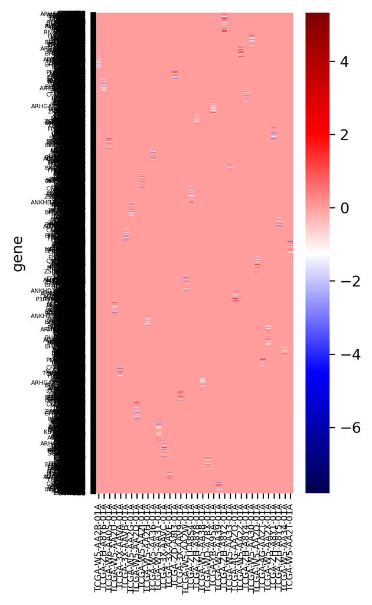

```python
display(Image('heatmap.png',width=1000))
```

Конечно, получилось очень плохо:гены все замылены

Выход разбить heatmap на кластеры и рассмотерть отдельно

## 10

Посмотрим на данные о выживаемости

```python
survival = pd.read_csv('TCGA-CHOL.survival.tsv', sep='\t')
survival.head()
```

|  | sample | OS | _PATIENT | OS.time |
| --- | --- | --- | --- | --- |
| 0 | TCGA-W5-AA31-01A | 0 | TCGA-W5-AA31 | 10 |
| 1 | TCGA-W5-AA31-11A | 0 | TCGA-W5-AA31 | 10 |
| 2 | TCGA-WD-A7RX-01A | 1 | TCGA-WD-A7RX | 21 |
| 3 | TCGA-YR-A95A-01A | 1 | TCGA-YR-A95A | 26 |
| 4 | TCGA-4G-AAZR-11A | 1 | TCGA-4G-AAZR | 28 |

```python
ids = survival['_PATIENT']
survival[ids.isin(ids[ids.duplicated()])].sort_values(by = '_PATIENT')
```

|  | sample | OS | _PATIENT | OS.time |
| --- | --- | --- | --- | --- |
| 62 | TCGA-4G-AAZF-11A | 0 | TCGA-4G-AAZF | 1777 |
| 61 | TCGA-4G-AAZF-01A | 0 | TCGA-4G-AAZF | 1777 |
| 46 | TCGA-4G-AAZO-11A | 0 | TCGA-4G-AAZO | 1177 |
| 45 | TCGA-4G-AAZO-01A | 0 | TCGA-4G-AAZO | 1177 |
| 4 | TCGA-4G-AAZR-11A | 1 | TCGA-4G-AAZR | 28 |
| 5 | TCGA-4G-AAZR-01A | 1 | TCGA-4G-AAZR | 28 |
| 20 | TCGA-4G-AAZT-11A | 0 | TCGA-4G-AAZT | 420 |
| 19 | TCGA-4G-AAZT-01A | 0 | TCGA-4G-AAZT | 420 |
| 66 | TCGA-W5-AA2I-01A | 1 | TCGA-W5-AA2I | 1939 |
| 65 | TCGA-W5-AA2I-11A | 1 | TCGA-W5-AA2I | 1939 |
| 30 | TCGA-W5-AA2O-01A | 1 | TCGA-W5-AA2O | 640 |
| 31 | TCGA-W5-AA2O-11A | 1 | TCGA-W5-AA2O | 640 |
| 6 | TCGA-W5-AA2Q-11A | 0 | TCGA-W5-AA2Q | 50 |
| 7 | TCGA-W5-AA2Q-01A | 0 | TCGA-W5-AA2Q | 50 |
| 57 | TCGA-W5-AA2R-01A | 0 | TCGA-W5-AA2R | 1542 |
| 56 | TCGA-W5-AA2R-11A | 0 | TCGA-W5-AA2R | 1542 |
| 48 | TCGA-W5-AA2T-11A | 1 | TCGA-W5-AA2T | 1220 |
| 47 | TCGA-W5-AA2T-01A | 1 | TCGA-W5-AA2T | 1220 |
| 28 | TCGA-W5-AA2U-01A | 1 | TCGA-W5-AA2U | 627 |
| 29 | TCGA-W5-AA2U-11A | 1 | TCGA-W5-AA2U | 627 |
| 15 | TCGA-W5-AA2X-01A | 1 | TCGA-W5-AA2X | 271 |
| 14 | TCGA-W5-AA2X-11A | 1 | TCGA-W5-AA2X | 271 |
| 59 | TCGA-W5-AA2Z-01A | 0 | TCGA-W5-AA2Z | 1614 |
| 58 | TCGA-W5-AA2Z-11A | 0 | TCGA-W5-AA2Z | 1614 |
| 43 | TCGA-W5-AA30-01A | 0 | TCGA-W5-AA30 | 1153 |
| 44 | TCGA-W5-AA30-11A | 0 | TCGA-W5-AA30 | 1153 |
| 0 | TCGA-W5-AA31-01A | 0 | TCGA-W5-AA31 | 10 |
| 1 | TCGA-W5-AA31-11A | 0 | TCGA-W5-AA31 | 10 |
| 53 | TCGA-W5-AA33-01A | 0 | TCGA-W5-AA33 | 1449 |
| 54 | TCGA-W5-AA33-11A | 0 | TCGA-W5-AA33 | 1449 |
| 24 | TCGA-W5-AA34-11A | 1 | TCGA-W5-AA34 | 555 |
| 25 | TCGA-W5-AA34-01A | 1 | TCGA-W5-AA34 | 555 |
| 51 | TCGA-W7-A93N-01A | 0 | TCGA-W7-A93N | 1441 |
| 52 | TCGA-W7-A93N-11A | 0 | TCGA-W7-A93N | 1441 |
| 12 | TCGA-W7-A93O-01A | 0 | TCGA-W7-A93O | 180 |
| 13 | TCGA-W7-A93O-11A | 0 | TCGA-W7-A93O | 180 |
| 63 | TCGA-W7-A93P-11A | 0 | TCGA-W7-A93P | 1777 |
| 64 | TCGA-W7-A93P-01A | 0 | TCGA-W7-A93P | 1777 |
| 9 | TCGA-ZU-A8S4-11A | 1 | TCGA-ZU-A8S4 | 98 |
| 8 | TCGA-ZU-A8S4-01A | 1 | TCGA-ZU-A8S4 | 98 |

Метод Каплана- Мейера Метод Каплана-Мейера — это непараметрический метод анализа выживаемости. Он не предполагает конкретного распределения времени выживания и не предполагает связи между временем выживания и независимыми переменными.

Метод Каплана-Мейера оценивает вероятность выживания по наблюдаемому времени выживания (как цензурированному, так и нецензурированному). Вероятность выживания построена в зависимости от времени t на кривой выживания Каплана-Мейера. Кривая выживания полезна для понимания среднего времени выживания (время, при котором вероятность выживания составляет 50%).

Данные OS показывают есть ли рецедив(смерть) 0-нет(либо наоборот). OS.time- показывает время наступления события OS

Метод Каплана-Мейера подходит для простого анализа выживаемости и не учитывает другие независимые переменные (вмешивающиеся факторы) при анализе кривых выживаемости. Если есть другие смешанные факторы, которые вы хотите включить в модель, вы должны использовать модель пропорциональных рисков Кокса (PH) (регрессия Кокса).

Функция выживания Каплана – Мейера задается как

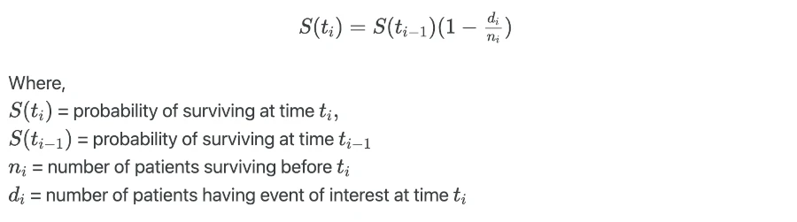

```python
survival['_PATIENT'].unique()
```

```
array(['TCGA-W5-AA31', 'TCGA-WD-A7RX', 'TCGA-YR-A95A', 'TCGA-4G-AAZR',
       'TCGA-W5-AA2Q', 'TCGA-ZU-A8S4', 'TCGA-ZD-A8I3', 'TCGA-W5-AA39',
       'TCGA-W7-A93O', 'TCGA-W5-AA2X', 'TCGA-3X-AAV9', 'TCGA-ZH-A8Y1',
       'TCGA-3X-AAVB', 'TCGA-4G-AAZT', 'TCGA-3X-AAVA', 'TCGA-ZH-A8Y6',
       'TCGA-W5-AA2M', 'TCGA-W5-AA34', 'TCGA-ZH-A8Y3', 'TCGA-ZH-A8Y8',
       'TCGA-W5-AA2U', 'TCGA-W5-AA2O', 'TCGA-3X-AAVE', 'TCGA-W6-AA0T',
       'TCGA-ZH-A8Y2', 'TCGA-3X-AAVC', 'TCGA-ZH-A8Y4', 'TCGA-ZH-A8Y7',
       'TCGA-W6-AA0S', 'TCGA-W5-AA2K', 'TCGA-W5-AA2J', 'TCGA-W5-AA2W',
       'TCGA-W5-AA2H', 'TCGA-W5-AA30', 'TCGA-4G-AAZO', 'TCGA-W5-AA2T',
       'TCGA-ZH-A8Y5', 'TCGA-W5-AA36', 'TCGA-W7-A93N', 'TCGA-W5-AA33',
       'TCGA-W5-AA38', 'TCGA-W5-AA2R', 'TCGA-W5-AA2Z', 'TCGA-4G-AAZG',
       'TCGA-4G-AAZF', 'TCGA-W7-A93P', 'TCGA-W5-AA2I', 'TCGA-W5-AA2G'],
      dtype=object)
```

```python
survival['OS'].unique()
```

```
array([0, 1], dtype=int64)
```

```python
survival
```

|  | sample | OS | _PATIENT | OS.time |
| --- | --- | --- | --- | --- |
| 0 | TCGA-W5-AA31-01A | 0 | TCGA-W5-AA31 | 10 |
| 1 | TCGA-W5-AA31-11A | 0 | TCGA-W5-AA31 | 10 |
| 2 | TCGA-WD-A7RX-01A | 1 | TCGA-WD-A7RX | 21 |
| 3 | TCGA-YR-A95A-01A | 1 | TCGA-YR-A95A | 26 |
| 4 | TCGA-4G-AAZR-11A | 1 | TCGA-4G-AAZR | 28 |
| ... | ... | ... | ... | ... |
| 63 | TCGA-W7-A93P-11A | 0 | TCGA-W7-A93P | 1777 |
| 64 | TCGA-W7-A93P-01A | 0 | TCGA-W7-A93P | 1777 |
| 65 | TCGA-W5-AA2I-11A | 1 | TCGA-W5-AA2I | 1939 |
| 66 | TCGA-W5-AA2I-01A | 1 | TCGA-W5-AA2I | 1939 |
| 67 | TCGA-W5-AA2G-01A | 0 | TCGA-W5-AA2G | 1976 |

68 rows × 4 columns

```python
%%R
library(survival)
```

```python
%%R
aml = read.csv('TCGA-CHOL.survival.tsv', sep='\t')
fit = survfit(Surv(OS.time, OS) ~ 1, data=aml)
```

```python
%%R
fit
```

```
Call: survfit(formula = Surv(OS.time, OS) ~ 1, data = aml)

      n  events  median 0.95LCL 0.95UCL
     68      30    1402     741      NA
```

```python
%%R
summary(fit)
```

```
Call: survfit(formula = Surv(OS.time, OS) ~ 1, data = aml)

 time n.risk n.event survival std.err lower 95% CI upper 95% CI
   21     66       1    0.985  0.0150       0.9558        1.000
   26     65       1    0.970  0.0211       0.9292        1.000
   28     64       2    0.939  0.0294       0.8836        0.999
   98     60       2    0.908  0.0358       0.8406        0.981
  169     58       1    0.892  0.0384       0.8202        0.971
  170     57       1    0.877  0.0408       0.8003        0.961
  271     54       2    0.844  0.0453       0.7600        0.938
  339     52       1    0.828  0.0473       0.7404        0.926
  385     51       1    0.812  0.0490       0.7212        0.914
  445     47       1    0.795  0.0510       0.7007        0.901
  540     45       1    0.777  0.0528       0.6800        0.888
  555     44       2    0.742  0.0560       0.6396        0.860
  561     42       1    0.724  0.0574       0.6198        0.846
  627     40       2    0.688  0.0599       0.5797        0.816
  640     38       2    0.652  0.0620       0.5407        0.785
  701     34       1    0.632  0.0631       0.5201        0.769
  741     32       1    0.613  0.0641       0.4990        0.752
  833     29       1    0.591  0.0653       0.4764        0.734
  924     27       1    0.570  0.0665       0.4531        0.716
 1220     21       2    0.515  0.0703       0.3944        0.673
 1402     18       1    0.487  0.0720       0.3642        0.650
 1939      3       2    0.162  0.1346       0.0319        0.825
```

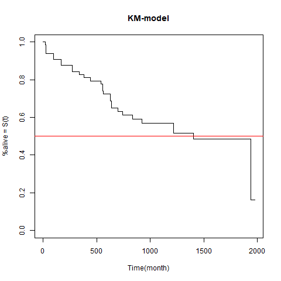

```python
%%R
plot(fit, conf.int=F,xlab= 'Time(month)', ylab="%alive = S(t)", main = "KM-model")
abline(h=0.5, col='red')
```

```python
%%R
library(dplyr)
```

[output not shown]

```python
%%R
aml_1 = distinct(aml,X_PATIENT, .keep_all= TRUE)
```

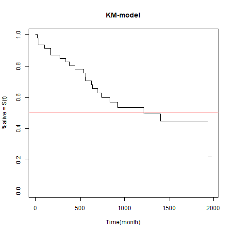

```python
%%R
fit = survfit(Surv(OS.time, OS) ~ 1, data=aml_1)
plot(fit, conf.int=F,xlab= 'Time(month)', ylab="%alive = S(t)", main = "KM-model")
abline(h=0.5, col='red')
```

```python
%%R
fit
```

```
Call: survfit(formula = Surv(OS.time, OS) ~ 1, data = aml_1)

      n  events  median 0.95LCL 0.95UCL
     48      22    1220     701      NA
```

Так как в таблице были повторяющиеся пациенты, которые отличались лишь сэмплами , я решила их убрать и посмотреть, что будет с графиком выживаемости, и, как я и догадывалась, он изменился. Думаю, стоит полагаться на второй график

## 11

Установила DESeq2 (Love et al, 2014) в окружение. Этот пакет нужен для параметрического анализа дифференциальной экспрессии и использует обобщённые линейные модели. На вход он получает матрицу с ненормированными каунтами (не TPM и не RPKM).

```python
%%R
if (!requireNamespace("BiocManager", quietly = TRUE))
    install.packages("BiocManager")

BiocManager::install("DESeq2")

library("DESeq2")
library(ggplot2)
```

[output not shown]

```
Update all/some/none? [a/s/n]: n
```

[output not shown]

[output cut: 111 more lines]

[output not shown]

```python
%%R
if (!requireNamespace("BiocManager", quietly = TRUE))
    install.packages("BiocManager")
library("DESeq2")
library(ggplot2)
```

```python
%%R
ensemblID = read.csv('TCGA-CHOL.htseq_counts.tsv', sep = '\t')
head(ensemblID)
```

```
          Ensembl_ID TCGA.ZD.A8I3.01A TCGA.W5.AA2U.11A TCGA.W5.AA30.01A
1 ENSG00000000003.13        12.359475        11.274378        12.325587
2  ENSG00000000005.5         1.000000         1.000000         0.000000
3 ENSG00000000419.11        10.244364         9.357552        10.683872
4 ENSG00000000457.12         9.558421         8.438792        11.373409
5 ENSG00000000460.15         8.535275         5.129283        10.029287
6 ENSG00000000938.11         7.169925         8.285402         8.566054
  TCGA.W5.AA38.01A TCGA.W5.AA30.11A TCGA.YR.A95A.01A TCGA.W5.AA36.01A
1        13.010178        11.591522        13.300210        11.290595
2         1.000000         1.000000         3.459432         0.000000
3        10.728771         9.315150        10.315150        10.314017
4         9.022368         8.550747        10.004220         8.980140
5         8.219169         6.629357         7.383704         6.954196
6         7.515700         7.870365         7.247928         7.584963
  TCGA.W5.AA2U.01A TCGA.ZH.A8Y2.01A TCGA.3X.AAVB.01A TCGA.W5.AA2Z.01A
```

[output cut: 69 more lines]

```python
ensemblId = pd.read_csv('TCGA-CHOL.htseq_counts.tsv', sep = '\t')
```

```python
ensemblId = ensemblId.set_index(ensemblId.columns[0])
ensemblId.head()
```

| Ensembl_ID | TCGA-ZD-A8I3-01A | TCGA-W5-AA2U-11A | TCGA-W5-AA30-01A | TCGA-W5-AA38-01A | TCGA-W5-AA30-11A | TCGA-YR-A95A-01A | TCGA-W5-AA36-01A | TCGA-W5-AA2U-01A | TCGA-ZH-A8Y2-01A | TCGA-3X-AAVB-01A | ... | TCGA-W5-AA2Q-11A | TCGA-W5-AA31-11A | TCGA-W5-AA2Q-01A | TCGA-W5-AA33-01A | TCGA-W5-AA2X-11A | TCGA-4G-AAZT-01A | TCGA-3X-AAV9-01A | TCGA-ZU-A8S4-11A | TCGA-W5-AA2I-01A | TCGA-W5-AA2G-01A |
| --- | --- | --- | --- | --- | --- | --- | --- | --- | --- | --- | --- | --- | --- | --- | --- | --- | --- | --- | --- | --- | --- |
| ENSG00000000003.13 | 12.359475 | 11.274378 | 12.325587 | 13.010178 | 11.591522 | 13.300210 | 11.290595 | 12.863218 | 12.727070 | 10.967226 | ... | 10.908393 | 12.105254 | 12.185805 | 13.469515 | 11.186733 | 12.880923 | 11.715962 | 12.004220 | 12.051889 | 10.796040 |
| ENSG00000000005.5 | 1.000000 | 1.000000 | 0.000000 | 1.000000 | 1.000000 | 3.459432 | 0.000000 | 1.000000 | 0.000000 | 1.584963 | ... | 2.000000 | 2.807355 | 0.000000 | 1.000000 | 0.000000 | 0.000000 | 1.000000 | 0.000000 | 0.000000 | 0.000000 |
| ENSG00000000419.11 | 10.244364 | 9.357552 | 10.683872 | 10.728771 | 9.315150 | 10.315150 | 10.314017 | 10.224002 | 10.320801 | 10.415742 | ... | 8.867279 | 9.749869 | 10.355351 | 9.932215 | 9.491853 | 10.131857 | 10.817783 | 9.535275 | 9.623881 | 10.344296 |
| ENSG00000000457.12 | 9.558421 | 8.438792 | 11.373409 | 9.022368 | 8.550747 | 10.004220 | 8.980140 | 10.209453 | 9.818582 | 9.192293 | ... | 8.392317 | 9.124121 | 12.228518 | 10.587778 | 8.682995 | 8.658211 | 9.233620 | 8.290019 | 9.481799 | 9.353147 |
| ENSG00000000460.15 | 8.535275 | 5.129283 | 10.029287 | 8.219169 | 6.629357 | 7.383704 | 6.954196 | 8.103288 | 8.738092 | 7.900867 | ... | 6.266787 | 6.954196 | 9.882643 | 8.611025 | 6.392317 | 7.000000 | 7.924813 | 7.417853 | 8.266787 | 7.679480 |

5 rows × 45 columns

Далее мы перегружаем наш датафрейм из Python в R, чтобы работать с ним там. Округлим наши экспрессии, чтобы они стали целочисленными (DESeq2 не умеет работать с нецелыми значениями каунтов) — для этого жёстко обозначим тип данных экспрессии как int32.

```python
ensemblId = ensemblId.astype('int32')
```

```python
%R -i ensemblId
```

```python
%%R
head(ensemblId)
```

```
                   TCGA-ZD-A8I3-01A TCGA-W5-AA2U-11A TCGA-W5-AA30-01A
ENSG00000000003.13               12               11               12
ENSG00000000005.5                 1                1                0
ENSG00000000419.11               10                9               10
ENSG00000000457.12                9                8               11
ENSG00000000460.15                8                5               10
ENSG00000000938.11                7                8                8
                   TCGA-W5-AA38-01A TCGA-W5-AA30-11A TCGA-YR-A95A-01A
ENSG00000000003.13               13               11               13
ENSG00000000005.5                 1                1                3
ENSG00000000419.11               10                9               10
ENSG00000000457.12                9                8               10
ENSG00000000460.15                8                6                7
ENSG00000000938.11                7                7                7
                   TCGA-W5-AA36-01A TCGA-W5-AA2U-01A TCGA-ZH-A8Y2-01A
ENSG00000000003.13               11               12               12
ENSG00000000005.5                 0                1                0
ENSG00000000419.11               10               10               10
ENSG00000000457.12                8               10                9
ENSG00000000460.15                6                8                8
ENSG00000000938.11                7                8                8
                   TCGA-3X-AAVB-01A TCGA-W5-AA2Z-01A TCGA-W5-AA2X-01A
ENSG00000000003.13               10               12               11
ENSG00000000005.5                 1                0                0
ENSG00000000419.11               10               10               10
ENSG00000000457.12                9               10               10
ENSG00000000460.15                7                8                9
ENSG00000000938.11                8                8                7
                   TCGA-W5-AA34-11A TCGA-ZH-A8Y6-01A TCGA-ZH-A8Y1-01A
ENSG00000000003.13               12                9               10
ENSG00000000005.5                 0                0                0
ENSG00000000419.11                9               10                9
ENSG00000000457.12                9               10               10
ENSG00000000460.15                6                7                8
ENSG00000000938.11                6                6                8
                   TCGA-ZU-A8S4-01A TCGA-W5-AA2R-01A TCGA-W5-AA2H-01A
ENSG00000000003.13               10               12                7
ENSG00000000005.5                 0                1                2
ENSG00000000419.11               10               10               10
ENSG00000000457.12                8               10                9
```

[output cut: 50 more lines]

```
ENSG00000000938.11                7                6                9
                   TCGA-W5-AA2X-11A TCGA-4G-AAZT-01A TCGA-3X-AAV9-01A
ENSG00000000003.13               11               12               11
ENSG00000000005.5                 0                0                1
ENSG00000000419.11                9               10               10
ENSG00000000457.12                8                8                9
ENSG00000000460.15                6                7                7
ENSG00000000938.11                8                7                9
                   TCGA-ZU-A8S4-11A TCGA-W5-AA2I-01A TCGA-W5-AA2G-01A
ENSG00000000003.13               12               12               10
ENSG00000000005.5                 0                0                0
ENSG00000000419.11                9                9               10
ENSG00000000457.12                8                9                9
ENSG00000000460.15                7                8                7
ENSG00000000938.11                8                6                8
```

```python
phenotype = phenotype.set_index(phenotype.columns[0])
phenotype.head()
```

| submitter_id.samples | age_at_initial_pathologic_diagnosis | albumin_result_lower_limit | albumin_result_specified_value | albumin_result_upper_limit | batch_number | bcr | bcr_followup_barcode | bcr_followup_uuid | submitter_id | bilirubin_lower_limit | ... | days_to_collection.samples | days_to_sample_procurement.samples | initial_weight.samples | is_ffpe.samples | oct_embedded.samples | preservation_method.samples | sample_type.samples | sample_type_id.samples | state.samples | tissue_type.samples |
| --- | --- | --- | --- | --- | --- | --- | --- | --- | --- | --- | --- | --- | --- | --- | --- | --- | --- | --- | --- | --- | --- |
| TCGA-ZH-A8Y2-01A | 59.0 | NaN | NaN | NaN | 428.25.0 | Nationwide Children's Hospital | NaN | NaN | TCGA-ZH-A8Y2 | NaN | ... | 897.0 | NaN | 400.0 | False | False | NaN | Primary Tumor | 1 | released | Not Reported |
| TCGA-ZH-A8Y7-01A | 59.0 | 3.5 | 2.4 | 5.0 | 448.13.0 | Nationwide Children's Hospital | NaN | NaN | TCGA-ZH-A8Y7 | 0.2 | ... | 77.0 | NaN | 1100.0 | False | False | NaN | Primary Tumor | 1 | released | Not Reported |
| TCGA-W7-A93O-01A | NaN | NaN | NaN | NaN | 448.13.0 | Nationwide Children's Hospital | NaN | NaN | TCGA-W7-A93O | 78.0 | ... | 465.0 | NaN | 180.0 | False | True | NaN | Primary Tumor | 1 | released | Not Reported |
| TCGA-W7-A93O-11A | NaN | NaN | NaN | NaN | 448.13.0 | Nationwide Children's Hospital | NaN | NaN | TCGA-W7-A93O | 78.0 | ... | 465.0 | NaN | 180.0 | False | True | NaN | Solid Tissue Normal | 11 | released | Not Reported |
| TCGA-W5-AA30-01A | 82.0 | 3.5 | 4.3 | 5.0 | 428.25.0 | Nationwide Children's Hospital | TCGA-W5-AA30-F66610 | B7D96997-EC27-438D-95D7-16B1817F93FB | TCGA-W5-AA30 | 0.1 | ... | 1134.0 | NaN | 200.0 | False | True | NaN | Primary Tumor | 1 | released | Not Reported |

5 rows × 121 columns

```python
%%R
phenotype =read.csv('TCGA-CHOL.GDC_phenotype.tsv',  sep = '\t', row.names = 1, header= TRUE)
```

```python
%%R
head(phenotype)
```

```
                 age_at_initial_pathologic_diagnosis albumin_result_lower_limit
TCGA-ZH-A8Y2-01A                                  59                         NA
TCGA-ZH-A8Y7-01A                                  59                        3.5
TCGA-W7-A93O-01A                                  NA                         NA
TCGA-W7-A93O-11A                                  NA                         NA
TCGA-W5-AA30-01A                                  82                        3.5
TCGA-W5-AA30-11A                                  82                        3.5
                 albumin_result_specified_value albumin_result_upper_limit
TCGA-ZH-A8Y2-01A                             NA                         NA
TCGA-ZH-A8Y7-01A                            2.4                          5
TCGA-W7-A93O-01A                             NA                         NA
TCGA-W7-A93O-11A                             NA                         NA
TCGA-W5-AA30-01A                            4.3                          5
TCGA-W5-AA30-11A                            4.3                          5
                 batch_number                            bcr
TCGA-ZH-A8Y2-01A     428.25.0 Nationwide Children's Hospital
TCGA-ZH-A8Y7-01A     448.13.0 Nationwide Children's Hospital
TCGA-W7-A93O-01A     448.13.0 Nationwide Children's Hospital
TCGA-W7-A93O-11A     448.13.0 Nationwide Children's Hospital
TCGA-W5-AA30-01A     428.25.0 Nationwide Children's Hospital
TCGA-W5-AA30-11A     428.25.0 Nationwide Children's Hospital
                 bcr_followup_barcode                    bcr_followup_uuid
TCGA-ZH-A8Y2-01A
TCGA-ZH-A8Y7-01A
TCGA-W7-A93O-01A
TCGA-W7-A93O-11A
TCGA-W5-AA30-01A  TCGA-W5-AA30-F66610 B7D96997-EC27-438D-95D7-16B1817F93FB
TCGA-W5-AA30-11A  TCGA-W5-AA30-F66610 B7D96997-EC27-438D-95D7-16B1817F93FB
                 submitter_id bilirubin_lower_limit bilirubin_upper_limit
TCGA-ZH-A8Y2-01A TCGA-ZH-A8Y2                    NA                    NA
TCGA-ZH-A8Y7-01A TCGA-ZH-A8Y7                   0.2                   0.3
TCGA-W7-A93O-01A TCGA-W7-A93O                  78.0                   2.1
TCGA-W7-A93O-11A TCGA-W7-A93O                  78.0                   2.1
TCGA-W5-AA30-01A TCGA-W5-AA30                   0.1                   0.9
TCGA-W5-AA30-11A TCGA-W5-AA30                   0.1                   0.9
                 ca_19_9_level ca_19_9_level_lower ca_19_9_level_upper
TCGA-ZH-A8Y2-01A            NA                  NA                  NA
TCGA-ZH-A8Y7-01A          39.1                   0                36.9
TCGA-W7-A93O-01A            NA                  NA                  NA
TCGA-W7-A93O-11A            NA                  NA                  NA
```

[output cut: 358 more lines]

```
TCGA-W5-AA30-11A           False                 true
                 preservation_method.samples sample_type.samples
TCGA-ZH-A8Y2-01A                          NA       Primary Tumor
TCGA-ZH-A8Y7-01A                          NA       Primary Tumor
TCGA-W7-A93O-01A                          NA       Primary Tumor
TCGA-W7-A93O-11A                          NA Solid Tissue Normal
TCGA-W5-AA30-01A                          NA       Primary Tumor
TCGA-W5-AA30-11A                          NA Solid Tissue Normal
                 sample_type_id.samples state.samples tissue_type.samples
TCGA-ZH-A8Y2-01A                      1      released        Not Reported
TCGA-ZH-A8Y7-01A                      1      released        Not Reported
TCGA-W7-A93O-01A                      1      released        Not Reported
TCGA-W7-A93O-11A                     11      released        Not Reported
TCGA-W5-AA30-01A                      1      released        Not Reported
TCGA-W5-AA30-11A                     11      released        Not Reported
```

Крайне важно, чтобы столбцы матрицы подсчета и строки данных столбца (информация об образцах) находились в одном и том же порядке. DESeq2 не будет делать предположения относительно того, какой столбец матрицы счета принадлежит какой строке данных столбца, они должны быть предоставлены DESeq2 уже в согласованном порядке.

Поскольку они расположены не в правильном порядке, как указано, нам нужно переставить один или другой так, чтобы они были согласованы с точки зрения порядка выборки (если мы этого не сделаем, более поздние функции вызовут ошибку).

```python
%%R
all(colnames(ensemblId) %in% rownames(phenotype))
```

```
[1] TRUE
```

```python
%%R
all(colnames(ensemblId) == rownames(phenotype))
```

```
[1] FALSE
```

```python
%%R
phenotype = phenotype[colnames(ensemblId), ]
all(rownames(phenotype) == colnames(ensemblId))
```

```
[1] TRUE
```

```python
%%R
dds = DESeqDataSetFromMatrix(countData = ensemblId,
                              colData = phenotype,
                              design = ~tumor_stage.diagnoses)
dds
```

```
R[write to console]:   Note: levels of factors in the design contain characters other than
  letters, numbers, '_' and '.'. It is recommended (but not required) to use
  only letters, numbers, and delimiters '_' or '.', as these are safe characters
  for column names in R. [This is a message, not a warning or an error]
```

```
class: DESeqDataSet
dim: 60488 45
metadata(1): version
assays(1): counts
rownames(60488): ENSG00000000003.13 ENSG00000000005.5 ... __not_aligned
  __alignment_not_unique
rowData names(0):
colnames(45): TCGA-ZD-A8I3-01A TCGA-W5-AA2U-11A ... TCGA-W5-AA2I-01A
  TCGA-W5-AA2G-01A
colData names(121): age_at_initial_pathologic_diagnosis
  albumin_result_lower_limit ... state.samples tissue_type.samples
```

```python
%%R
dds <- DESeq(dds)
```

[output not shown]

```python
%%R
print(dds)
```

```
class: DESeqDataSet
dim: 60488 45
metadata(1): version
assays(6): counts mu ... replaceCounts replaceCooks
rownames(60488): ENSG00000000003.13 ENSG00000000005.5 ... __not_aligned
  __alignment_not_unique
rowData names(39): baseMean baseVar ... maxCooks replace
colnames(45): TCGA-ZD-A8I3-01A TCGA-W5-AA2U-11A ... TCGA-W5-AA2I-01A
  TCGA-W5-AA2G-01A
colData names(123): age_at_initial_pathologic_diagnosis
  albumin_result_lower_limit ... sizeFactor replaceable
```

```python
%%R
res <- results(dds)
head(results(dds))
```

```
log2 fold change (MLE): tumor stage.diagnoses stage.ivb vs stage.i
Wald test p-value: tumor stage.diagnoses stage.ivb vs stage.i
DataFrame with 6 rows and 6 columns
                    baseMean log2FoldChange     lfcSE       stat    pvalue
                   <numeric>      <numeric> <numeric>  <numeric> <numeric>
ENSG00000000003.13 11.305965    -0.07283583  0.248535 -0.2930611  0.769475
ENSG00000000005.5   0.584728    -0.64646469  1.331710 -0.4854394  0.627365
ENSG00000000419.11  9.648947     0.00335516  0.264722  0.0126743  0.989888
ENSG00000000457.12  9.237979     0.01734437  0.272119  0.0637383  0.949179
ENSG00000000460.15  7.344476     0.04880531  0.303071  0.1610360  0.872065
ENSG00000000938.11  7.498513    -0.11889680  0.310383 -0.3830650  0.701672
                        padj
                   <numeric>
ENSG00000000003.13  0.999981
ENSG00000000005.5   0.999981
ENSG00000000419.11  0.999981
ENSG00000000457.12  0.999981
ENSG00000000460.15  0.999981
ENSG00000000938.11  0.999981
```

Упорядочим гены по p-value.

```python
%%R
res <- res[order(res$padj),]
head(res)
```

```
log2 fold change (MLE): tumor stage.diagnoses stage.ivb vs stage.i
Wald test p-value: tumor stage.diagnoses stage.ivb vs stage.i
DataFrame with 6 rows and 6 columns
                    baseMean log2FoldChange     lfcSE       stat    pvalue
                   <numeric>      <numeric> <numeric>  <numeric> <numeric>
ENSG00000000003.13 11.305965    -0.07283583  0.248535 -0.2930611  0.769475
ENSG00000000005.5   0.584728    -0.64646469  1.331710 -0.4854394  0.627365
ENSG00000000419.11  9.648947     0.00335516  0.264722  0.0126743  0.989888
ENSG00000000457.12  9.237979     0.01734437  0.272119  0.0637383  0.949179
ENSG00000000460.15  7.344476     0.04880531  0.303071  0.1610360  0.872065
ENSG00000000938.11  7.498513    -0.11889680  0.310383 -0.3830650  0.701672
                        padj
                   <numeric>
ENSG00000000003.13  0.999981
ENSG00000000005.5   0.999981
ENSG00000000419.11  0.999981
ENSG00000000457.12  0.999981
ENSG00000000460.15  0.999981
ENSG00000000938.11  0.999981
```

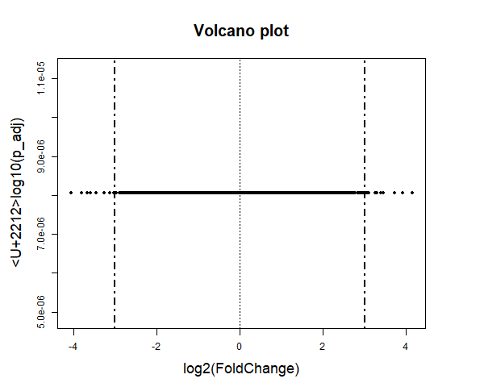

```python
%%R -w 600

#Задаём размер текста и композицию графика
par(mar=c(5,5,5,5), cex=1.0, cex.main=1.7, cex.axis=1, cex.lab=1.5)

#Отрисовываем все точки чёрным цветом
with(res, plot(log2FoldChange, -log10(padj), pch=20, main="Volcano plot", cex=1.0, xlab="log2(FoldChange)", ylab="−log10(p_adj)"))

#Отрисовываем точки, прошедшие порог, красным цветом
with(subset(res, padj<0.001 & abs(log2FoldChange)>3), points(log2FoldChange, -log10(padj), pch=20, col="red", cex=0.5))

#Отрисовываем линии с порогами
abline(v=0, col="black", lty=3, lwd=1.0)
abline(v=-3, col="black", lty=4, lwd=2.0)
abline(v=3, col="black", lty=4, lwd=2.0)
abline(h=3, col="black", lty=4, lwd=2.0)
```

Мне не нравится,что получилось, попробуем сделать по-другому.

```python
%%R
  if (!requireNamespace('BiocManager', quietly = TRUE))
    install.packages('BiocManager')

  BiocManager::install('EnhancedVolcano')
```

[output not shown]

[output cut: 186 more lines]

[output not shown]

[output not shown]

```
Update all/some/none? [a/s/n]: a
```

[output not shown]

[output not shown]

[output not shown]

[output not shown]

[output not shown]

[output not shown]

[output not shown]

[output not shown]

[output not shown]

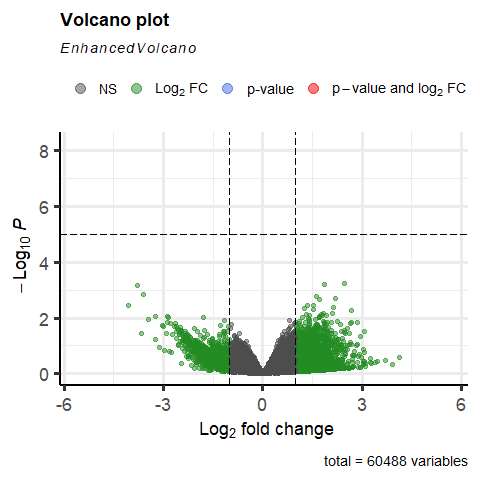

```python
%%R
library(EnhancedVolcano)
EnhancedVolcano(res, lab = rownames(res), x = 'log2FoldChange', y = 'pvalue')
```

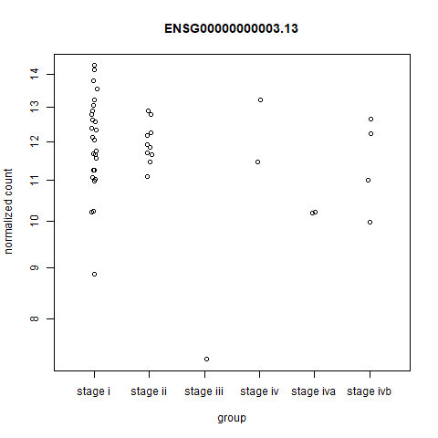

```python
%%R
plotCounts(dds, gene=which.min(res$padj), intgroup="tumor_stage.diagnoses")
```

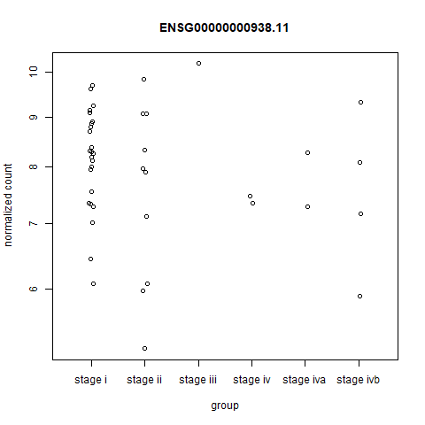

```python
%%R
plotCounts(dds, gene='ENSG00000000938.11' , intgroup="tumor_stage.diagnoses")
```